# note

##### 期中考题型

1. 判断题 10 * 2（需要说明原因或更正，只需要写一句话）
2. 选择题 5（单选） *2 不定项，1~4个答案）*2
3. 计算题 2 * 30
   1. 远期定价，远期价格&价值
   2. 国债期货，利率风险管理

科学计算器

##### 期末考题型

1. 范围：6~13章(第0章很重要)
2. 客观题为主，判断、选择、计算
3. 考试时间2H，计算题题量变大

### 金融工程概述

#### 风险管理方法

- 风险管理
  - 风险分散（投资组合理论）
  - 风险转移（金融工程）
    - 部分转移(期权)：有可能不行权，保留了部分不确定性
    - 全部转移（远期&期货）

#### 金融工程：本质&作用

- 金融衍生产品的本质透析：
  - 零和博弈；
  - 契约性. 虚拟性与未来性；
  - 高杠杆性；（反而可能造成更大的风险）
  - 衍生性
- 金融衍生产品的功能：
  - 风险管理功能；
  - 价格发现功能；
  - 信息功能
- 金融衍生产品的风险：如果监管和运用不当，则可能带来更大的风险

#### 金融产品定价理论

- 1896 欧文·费雪 & 直接定价法：$PV = \Sigma \frac{CF_{t}}{(1+r)^{t}} $（如何确定贴现率r？）
- 1938 麦考莱：“久期”. “利率免疫”
- 1952 马科维茨： “证券组合分析” Mean-Var Analysis
- 1960s 夏普：“资本资产定价模型”（CAPM）$E(r_{i})=r_{f}+β_{im}(E(r_{m})-r_{f})$ $β$衡量系统性风险
- 1973 布莱克. 舒尔斯 & 默顿：B-S期权定价模型
- 1980s 达菲： 拓展到不完全竞争市场

#### 衍生品定价的基本假设

- 市场不存在摩擦
- 市场参与者不承担对手风险（Counterparty Risk） （OTC产品定价变简单）
- 市场是完全竞争的
- 市场不存在无风险套利机会，或者说市场参与者认为财富越多越好 （用于检验价格“合理性”）

#### 连续复利（一年计息无数次的利率）

##### 各种计息频次利率与连续利率的转化公式

基础：令终值相等，列等式 $$e^{r} = (1+\frac{r_{m}}{m})^{m} = 1+r_{1}$$ 即可推出： $$r = m ln (1+\frac{r_{m}}{m}) $$

$$r_{m} = m(e^{\frac{r}{m}}-1)$$

尤其是当m = 1时： $$r = ln (1+r_{1}) = ln (P_{1})-ln (P_{0})$$

在股票投资场景中，由于对数收益率$ln (\frac{P_{1}}{P_{0}})$比百分比收益率$\frac{P_{1}-P_{0}}{P_{0}}$拥有正态性. 可连加性等优良性质，一般对数收益率更加常用

### 远期&期货概述

#### 远期合约种类

1. 远期*利率*协议（FRA）
   - 定义：买卖双方同意从未来某一商定的时刻开始，在某一特定时期内按协议利率借贷一笔数额确定. 以特定货币表示的名义本金的协议。
   - 通过事先约定利率，借款人可以规避利率上升的风险，贷款人则可以规避利率下跌的风险。无论未来利率升跌，FRA将实际贷款利率锁定为协议利率。
   - $1*4$：一个月后，借款3个月（至第四个月）
2. 远期*外汇*协议
   - 定义：双方约定在将来某一时间按约定的汇率买卖一定金额的某种外汇的合约
   - CNY:在岸市场的远期外汇交易，标的为在岸即期￥汇率；CNH：离岸市场的远期外汇交易，标的为离岸即期￥汇率；NDF:游离于监管之外的外汇市场，标的为在岸市场的￥汇率（CNY. CNH属于可交割的远期，即DF；NDF则无法交割本金,实际结算时使用其他可自由兑换的货币）
   - 买报价（bid）&卖报价（ask）：外汇的买/卖报价是针对银行而言的，银行买外汇时使用买价，卖出时使用卖价
   1. 远期*股票*合约

#### 期货

- 期货
  1. 定义
  2. 特点
  - 交易所内集中交易：信息优势，流动性好
    - 未平仓合约数：平仓时减少，建仓时增加
    - 当大部分交易为日内交易时，一天内的期货交易量（Volume of Trading）可能大于该日收盘时的未平仓合约数
  - 标准化合约：流动性好
  - 特殊的交易和交割制度：控制信用风险
    - 每日盯市结算（Marking to Market and Daily Settlement）
      - 每日盯市结算（mark to market）
      - 收盘价!=结算价
      - $F_{T}→S_{T}$：T时刻正好期货交割，所以期货与现货的价值是等同的，现货价格与期货价格应当相等
      - 基差 = S-F（有时候是F-S）在T时刻收敛于0
        - 投机力量主导时：基差主要受情绪主导
        - 套利力量主导时：基差主要受持仓成本主导

[figure not shown]

    - 保证金（Margin）制度
      - 初始保证金（initial margin）
      - 每日结算价格（Settlement Price）
      - 维持保证金（maintenance margin）
      - 保证金追加通知（margin call）
      - 当保证金账户余额小于维持保证金时，就需要追加保证金直至余额等于初始保证金
      - 交易保证金率：1）按期货合约价值确定。 一般为合约价值的一定比例。这种方法为我国的期货市场普遍采用。（2）按价格的变动量确定。主要是依据期货合约价格的变动量来确定保证金值。这种方法为国外交易所采用。
  1. 种类
     - 股票指数期货
     - 外汇期货
     - 利率期货

##### 标准化的合约条款

- 合约条款
  - 交易单位(trade unit)（或合约规模contract size）
    - 合约乘数：用于设置市场进入门槛
  - 到期时间
    - 到期循环与到期月（当月. 下个月. 随后2个季度月）
    - 交割月（若要避免麻烦的交割，就要在交割月前平仓）. 交割日. 现金结算日. 最后交易日（到期月的第三个周五）
  - 最小价格波动值（也称刻度值tick size）
  - 每日价格波动限制与交易中止规则
    - 涨停板（limit up）. 跌停板（limit down）
    - 熔断机制（circuit breaker）
  - 交割条款
    - 现金交割（结算并支付现金盈亏）和实物交割（一手交钱，一手交货），交割日期（由空头决定，因为空头可能需要选择有货的时间交货，所以期货价格可以降低一些）和交割地点等
  - 其他
    - 交易时间. 产品代码. 头寸限额（position limit，若非有现货者套期保值，一个人不可以持有过多某种合约的头寸）等

##### 期货市场监管

1. 监管机构

   ```
    + 期货监管部门：证监会/商品期货交易委员会(CFTC)
    + 国家期货协会（NFA）
    + 交易所和清算所
   ```

2. 市场操纵行为：逼仓（Market Corners）
   - 当多头同时掌控期货和现货，就有机会大幅度拉高价格，给空头很大压力

##### 与远期的不同（场内衍生品&场外衍生品的区别）

- 1. 交易场所不同
     - 远期并没有固定的交易场所， 买卖双方各自寻找合适的对象， 因而是一个无严格组织的分散市场。
     - 期货合约则在交易所内集中交易， 一般不允许场外交易。 交易所不仅为期货交易提供了交易场所和统一清算， 还为期货交易制定了许多严格的交易规则（ 如保证金制度 . 每日盯市结算制度 . 涨跌停板制度 . 最小价格波动值. 报价方式和最大持仓限额等） ， 并为期货交易提供信用担保。 可以说， 期货市场是一个有组织. 有秩序的统一市场。
  2. 标准化程度不同
     - 远期交易遵循“ 契约自由” 的原则， 合约中的相关条件如标的资产的质量. 数量. 交割地点和交割月份都是根据双方具体的需要确定的， 其条款的具体内容往往体现出很强的个性化特征。
     - 期货合约则是标准化的。 期货交易所为各种期货合约制定了标准化的数量. 质量. 交割地点. 交割时间. 交割方式. 合约规模等条款， 只有价格是在成交时根据市场行情确定的。
  3. 违约风险不同
     - 远期合约的履行主要取决于签约双方的信用， 一旦一方无力或不愿履约， 另一方就会蒙受损失。 目前国际主要远期市场的参与者大多需达到一定的资质， 并通过第三方或资产担保等方式降低远期交易的违约风险。
     - 期货合约的履行则由交易所或清算机构提供担保。 交易双方直接面对的都是交易所， 即使一方违约， 另一方也几乎不会受到影响。
  4. 合约双方关系不同
     - 远期合约是交易双方直接签订的， 而且由于远期合约的违约风险主要取决于交易对手的信用， 因此签约前通常要对交易对手的信誉和实力等方面作充分的了解。
     - 期货合约的履行完全不取决于对方， 只取决于交易所或清算机构， 交易所是所有买方的卖者和所有卖方的买者。 在期货交易中， 交易者根本无须知道对方是谁， 市场信息成本很低。
  5. 价格确定方式不同
     - 远期合约的交割价格是由交易双方直接谈判并私下确定的。
     - 期货交易的价格则是在交易所中通过公开竞价或根据做市商报价确定的。
  6. 结算方式不同
     - 远期交易是到期一次性结算的，所以在远期存续期内，实际交割价格始终不变，标的资产市场价格的变化给投资者带来的是账面浮动盈亏，到期结算时标的资产的市场价格与交割价格的差异才是投资者的真实盈亏。
     - 期货则有所不同。由于期货是*每日盯市结算*实现真实盈亏的，因此可以把期货看作一个每日以结算价平仓结清并以该结算价重新开立的合约，每日结算价格就是不断变动的期货交割价格。
     - 由于每天盯市结算，所以期货的最后结算价格仍然是T时刻的真实价格$F_{T}$；远期只进行一次结算，按照买入远期时的价格$F_{0}$交割
  7. 结清方式不同
     - 由于远期合约是非标准化的， 不易找到转让对象， 并要征得原交易对手的同意， 因此绝大多数远期合约只能通过到期实物交割或现金结算来结束。
     - 期货合约则可以通过到期交割结算和平仓两种方式结清。 由于交易便利， 期货交易一方无须征得对方同意就可通过平仓来结清自己的头寸并把履约权利和义务转让给第三方。在实际中， 绝大多数期货合约都是通过平仓来了结的。

### 远期&期货定价

- 商品
  - 投资性资产
    - 无红利资产（贴现债券 & 不付红利的股票）
    - 有红利资产
      - 已知红利资产
      - 已知*红利率*资产
  - 消费性资产

##### 卖空（Short Selling）

- 卖空（Short Selling）
  - 出售不拥有的资产
  - 向其他投资者借入该资产并卖出
  - 未来需买回归还
  - 此期间需支付原持有者应获得的股利等收入（红利是要还的）
- 卖空的限制：
  - A股的“卖空”：融券机制，只有融券名单上的资产可以卖空（借券费用很高！）
- 提升（uptick rules）:卖空需要提高报价
1. 无套利方法主要适用于投资性资产，不一定适用于消费性资产
2. 交割价格（Delivery Price）：合约所规定的固定价格 $K$
3. 远期价值：远期合约本身的价值（作为0成本的零和游戏，公平的远期价值应当是0）
4. 远期价格（Forward Price）：使得远期价值为0的合理交割价格 $F$
   - $K = F$时，远期价值为0， $K$ 是一个比较合理的价格

##### 远期价格&期货价格

1. 当无风险利率恒定且对所有到期日都相同时，其他条件相同的远期价格和期货价格相等。
2. 当利率变化无法预测时，两者略有不同 (P48，涉及保证金账户余额的变化)
   - 当标的资产价格与利率正相关时，期货价格高于远期价格
   - 当标的资产价格与利率负相关时，远期价格高于期货价格
3. 远期价格和期货价格的差异幅度还取决于：
   - 合约有效期. 税收. 交易费用. 保证金的处理方式. 违约风险. 流动性等

##### 基本假设

1. 没有交易费用和税收。
2. 市场参与者能以相同的无风险利率借入和贷出资金。
3. 允许现货卖空。
4. 没有违约风险。
5. 当套利机会出现时，市场参与者将参与套利活动，从而使套利机会消失。
   - 我们得到的理论价格就是*没有套利机会下的均衡价格*。
6. 期货合约的保证金账户支付同样的无风险利率。
   - 这意味着任何人均可不花成本地取得远期和期货的多头和空头地位
   - 此时期货价格 = 远期价格
- 前三条假设可以有条件放宽

##### 复制定价法

    \begin{array}{c|c|c|c|c} t & S \rightarrow -S & -S * B \rightarrow S & -1 * f \rightarrow 0 & 0 \\ \hline T & - 1*S \rightarrow 0 & +S * B \rightarrow -S e^{r(T-t)} & +1 * f \rightarrow K & K- S e^{r(T-t)} > 0 \end{array}
    - t时刻：套利者按无风险利率r借入现金S，期限为T-t。然后用S购买一单位标的资产，同时卖出一份该资产的远期合约，交割价格为K。
    - T时刻：该套利者将一单位标的资产交割换得现金K，并归还借款本息 $S*e^{r(T-t)}$，实现 $K - S*e^{r(T-t)}$ 的无风险利润
  - 若$K<S*e^{r(T-t)}$ （资产被低估，套利方向是做多标的资产）:

    \begin{array}{c|c|c|c|c} t & - 1*S \rightarrow S & +S * B \rightarrow -S & +1 * f \rightarrow 0 & 0 \\ \hline T & S \rightarrow 0 & -S * B \rightarrow S e^{r(T-t)} & -1 * f \rightarrow -K & S e^{r(T-t)}-K > 0 \end{array}
    - t时刻：套利者卖空标的资产获得现金S，以无风险利率r进行投资，期限为T-t。同时买进一份该标的资产的远期合约，交割价为K。
    - T时刻：套利者收到投资本息 $S*e^{r(T-t)}$，并以现金K交割换得一单位标的资产，用于归还卖空时借入的标的资产，从而实现 $S*e^{r(T-t)}-K$ 的无风险利润。
  - 第一列为时间点，第二至第四列为套利策略，第五列为总和现金流

##### 远期价格的期限结构

- $F$为$T$时刻交割的远期价格；$F^{*}$是$T^{*}$时刻交割的远期价格
- 根据定价公式，可得：$F = S e^{r(T-t)}$ $F^{*} = S e^{r^{*}(T^{*}-t)}$
- 二者相除消去S，可得：$F^{*} = F e^{r^{*}(T^{*}-t)-r(T-t)}$

##### 标的资产：支付已知红利的资产

    \begin{array}{c|c|c|c|c} t & S \rightarrow -S & -S * B \rightarrow S & -1 * f \rightarrow 0 & 0 \\ \hline T & - 1*S \rightarrow I * e^{r(T-t)} & -S * B \rightarrow -S e^{r(T-t)} & 1 * f \rightarrow K & K-(S-I) e^{r(T-t)} > 0 \end{array}
    - t时刻：套利者按无风险利率r借入现金S，期限为T-t。然后用S购买一单位标的资产，并卖出一份该资产的远期合约，交割价格为K。同时，将T-t期间从标的资产获得的现金收益以无风险利率r贷出至T时刻。
    - T时刻：该套利者将一单位标的资产交割换得现金K，并归还借款本息 $S*e^{r(T-t)}$，同时得到 $I*e^{r(T-t)}$ 的本利收入，最终实现 $K- (S-I)*e^{r(T-t)}$ 的无风险利润
  - 若$K < (S_{t} - I) e^{r(T-t)}$（资产被高估，套利方向是做空标的资产）

    \begin{array}{c|c|c|c|c} t & - 1*S \rightarrow S & +S * B \rightarrow -S & +1 * f \rightarrow 0 & 0 \\ \hline T & S \rightarrow -I * e^{r(T-t)} & -S * B \rightarrow S e^{r(T-t)} & 1 * f \rightarrow -K & (S-I) e^{r(T-t)}-K > 0 \end{array}
    - t时刻：套利者卖空标的资产获得现金S，以无风险利率r进行投资，期限为T-t。同时，买进一份该标的资产的远期合约，交割价格为K。
    - T时刻：套利者收到投资本息 $S*e^{r(T-t)}$ ，并以现金K交割换得一单位标的资产用于归还卖空时借入的标的资产，并把该标的资产在T-t期间的现金收益终值 $I* e^{r(T-t)}$ 同时归还标的资产原所有者，最终实现 $ (S-I)*e^{r(T-t)}-K$ 的无风险利润

##### 黄金存储问题

- 假设黄金现价为每盎司733美元，其存储成本为每年每盎司2美元，*一年后支付*，美元一年期无风险利率为4%
  - 已知现金“红利”的标的资产
  - $I = -2*e^{r(T-t)} = -2*e^{4 \% *1} = -1.92$
    - 按照已知现金红利的情况计算

##### 持有成本（Cost of Carry）

- 持有成本 = 保存成本+利息成本- 标的资产在合约期限内的收益
  - 例子：
    - 不支付红利的股票，持有成本是$c=r$
    - 股票指数，持有成本是$c=r - q$
    - 外币，持有成本是$c=r-r_{f}$
    - 黄金白银等，持有成本$c=r+u$
  - 定价公式可以用持有成本表示：
    - $F = S e^{c(T-t)}$
      - $f = S e^{(c-r)(T-t)} - K e^{r(T-t)}$

##### 不完美市场

1. 存在交易成本的时候，假定每一笔交易的费率为Y

   ```
    + 远期价格不再是具体值，而是一个区间：$[S(1-Y)e^{r(T-t)},S(1+Y)e^{r(T-t)}]$
    + 相当于在套利判定的不等式中加入了一个“楔子”
   ```

   1. 借贷存在利差的时候，如果用$r_{b}$表示借入利率，用$r_{l}$表示借出利率，对非银行的机构和个人，一般是$r_{b}>r_{l}$。
      - 此时的价格区间为：$[Se^{r_{l}(T-t)},Se^{r_{b}(T-t)}]$
      - 借入资金的价格上升，卖空投资的收益下降
   2. 存在卖空限制的时候，假设由于卖空限制导致的成本比例为X。
      - 此时的价格区间为：$[(1-X)Se^{r(T-t)},Se^{r(T-t)}]$
      - 上限不变，不存在限制；卖空存在X的成本
2. 假设以上情况同时存在：$[(1-X)S(1-Y)e^{r_{l}(T-t)},S(1+Y)e^{r_{b}(T-t)}]$

##### 消费性资产的远期定价

- 远期价格：$F \\leq S e^{c(T-t)}$
  - 原因：
    - 消费性资产具有消费价值（通常称之为便利收益），而远期合约却无法即时消费，消费性资产与其远期之间并不具有完全的可替代性。
- 因此即使在远期相对价值偏低的时候投资者也不会轻易出售现货，购买远期，从而使得单纯基于风险收益考虑的金融无套利原则不再完全有效。

##### $F_{t}$和$S_{t}$. $E(S_{t})$的关系

- 同一时刻远期（期货）价格与标的资产现货价格的关系：
  - 同一时刻的两者价格高低取决于持有成本（$F_{t} = S_{t} e^{c(T-t)}$）；在远期（期货）到期日，远期（期货）价格将收敛于标的资产的现货价格
  - 标的资产的现货价格对同一时刻的远期（期货）价格起着重要的制约关系（案例3.6 “327”国债期货事件）
  - 远期（期货）与现货的相对价格*只与持有成本c有关*，与未来现货的涨跌预期无关。
  - 价格的领先滞后关系（价格发现功能）
  - 预期收益率：$E(S_{t}) = S e^{y(T-t)}$ （当资产价格服从对数正态分布时成立，y表示预期收益率，$y = r + 风险溢酬$）
    - $F_{t}$和$E(S_{t})$的关系由y和r的大小关系决定

[figure not shown]

  - 在一个无套利的有效市场中，标的资产和其冗余证券期货之间具有一体化性质，期货的预期收益率总是正好等于标的资产的风险溢酬。
- 转移风险和管理风险是期货市场的最本质功能。

### 第四章 远期和期货的应用

##### 主要应用：

- 风险管理

  ```
    + 按多/空区分：
        + 多头（买入）风险管理
            + 通过做多远期或期货进行风险管理
            + 适合*担心价格上涨*的投资者，锁定未来买入价格
        + 空头（卖出）风险管理
            + 通过做空远期或期货进行风险管理
            + 适合*担心价格下跌*的投资者，锁定未来卖出价格
    + 按效果区分：
        + 完美的套期保值：
            + 能够完全消除价格风险的套期保值。 （注意：不是指价格不变，而是指未来的价格是确定的）
            + 远期（期货）的到期日. 标的资产和交易金额等条件的设定使得远期（期货）与现货恰好匹配。
        + 不完美的套期保值：
            + 无法完全消除价格风险的套期保值。
            + 常态

        + 原因：
            + 基差风险（Basis Risk）
                + 基差：特定时刻被套期保值的现货价格H 与用以进行套期保值的期货价格G之差（此时现货不一定是期货的标的资产，期货价格不一定等于理论价格）
                + b = H − G
                + 套保到期时基差的不确定性导致了不完美的套期保值
            + 数量风险（Quantity Risk）
                + 可能由于事先无法确知需要套期保值的标的资产规模
                + 可能由于期货合约的标准数量无法完全对冲现货的价格风险
                + 讨论*最优套期保值比率*时，通常不考虑数量风险
            + 相比远期，期货更加标准化，更不易实现完美套期保值

    + 运用远期或期货进行套期保值，消除了价格风险，但并不保证盈利。
        + 对于企业来说，完全对冲风险并非是最好的
    + 风险管理应该是针对企业的全局风险进行的，而不是针对局部风险。
        + eg. 炼油企业&原油期货：原油上涨，成品油也会上涨，因此企业应该通过做空来降低整体风险
  ```

  - 套利
    - 从第三章的定价方法出发，实际价格偏离理论价格即可套利
    - 在实际操作中，要考虑市场中各种“摩擦”
  - 投机
    - 从本质上看，远期（期货）与其标的资产价格变动的风险源是相同的，只是交割时间不同。
      - 因此远期（期货）与其标的资产现货之间往往存在着良好的替代关系，投机者通过承担价格变动的风险获取收益，既可以通过远期（期货）实现，也可以通过现货实现。
      - 远期（期货）优势在于进入成本低，具有高杠杆效应（双刃剑）。
      - 高杠杆：放大收益/放大亏损
      - $杠杆率 = \\frac{1}{保证金比率} $
    - 客观上，套期保值者和套利者往往不足以维持一个市场需要的流动性，此时适度投机可以起到提供流动性的作用。
      - 从这个意义上说，远期（期货）投机者不仅通过承担价格变动的市场风险，也通过承担流动性风险来获取风险收益。

##### 不完美套保

- 完美的套期保值：

  ```
    + 能够完全消除价格风险的套期保值。 （注意：不是指价格不变，而是指未来的价格是确定的）
    + 远期（期货）的到期日. 标的资产和交易金额等条件的设定使得远期（期货）与现货恰好匹配。
  ```

  - 不完美的套期保值：
    - 无法完全消除价格风险的套期保值。
    - 常态
  - 原因：
    - 基差风险（Basis Risk）
      - 基差：特定时刻被套期保值的现货价格H 与用以进行套期保值的期货价格G之差（此时现货不一定是期货的标的资产，期货价格不一定等于理论价格）
        - b = H(现货价格) − G(期货价格)
        - 现货多头&期货空头：$ W_{1} = (H_{1}-H_{0})+(G_{1}-G_{0}) = (H_{1}-G_{1})+(H_{0}-G_{0}) = b_{1}-b_{0} $,$b_{1}$是未知的，$b_{0}$是已知的，是否完美套保取决于$b_{1}$
        - 分解$b_{1}$：$b_{1}= H_{1}-G_{1} = (H_{1}-S_{1})+(S_{1}-G_{1})$,$S_{1}$为标的资产价格，若$H_{1}=S_{1}=G_{1}$,则$b_{1}=0$，达成完美套保
      - 套保到期时基差的不确定性导致了不完美的套期保值
      - 由于$b_{1}$的变动往往小于G的变化，所以不完美套保往往也能对冲风险
      - $b_{0}-b_{1}$减小→多头套保有利；$b_{1}-b_{0}$增大→空头套保有利
    - 数量风险（Quantity Risk）
      - 可能由于事先无法确知需要套期保值的标的资产规模
      - 可能由于期货合约的标准数量无法完全对冲现货的价格风险
      - 讨论*最优套期保值比率*时，通常不考虑数量风险
        - 相比远期，期货更加标准化，更不易实现完美套期保值

##### 套保策略

- 合约种类

  ```
    + 足够流动性 & 与现货资产高度相关
  ```

  - 到期日
    - 对于实物交割的期货而言，要避免在*期货到期的月份*中持有期货头寸，以防止逼仓。（避免麻烦的交割流程 & 交割月频繁的价格波动）
    - 在到期时间无法完全吻合时，通常选择比所需的套期保值*月份略晚但尽量接近*的期货品种。（避免期货价与现货价差距过大）
    - 所需套期保值时间较长时，可使用套期保值*展期*（快要到期时，平仓原有合约，购买期限更靠后的合约），但可能给套期保值者带来额外的风险。
  - 头寸方向
    - 价格上涨时不利→多头套保
    - 价格下跌时不利→空头套保
- 交易数量

##### 套保比率

- 套期保值比率（Hedge Ratio）是指用于套期保值的资产（如远期和期货）头寸对被套期保值的资产头寸的比率
  - $套期保值比率 = \\frac{用于套保的资产头寸}{被套保的资产头寸}$
  - 最优套期保值比率：能够最有效. 最大程度地消除被保值对象价格变动风险的套期保值比率。（最小的套保比率）
    - 存在基差风险时，最优套期保值比率很可能不为1

##### 最优套保比率（风险最小化的套保比率）

设1单位现货，n单位期货多头套保：

套保组合：$\Delta \Pi = n\Delta G- \Delta H$

最优套保条件(套保组合的价格变化不依赖于现货价格)：$\frac{\partial \Delta \Pi}{\partial \Delta H} = \frac{\partial (n\Delta G- \Delta H)}{\partial \Delta H} = n \frac{\partial \Delta G}{\partial \Delta H} -1 = 0$ → $n = \frac{\partial \Delta H}{\partial \Delta G}$

由于收益率$r_{H} = \frac{H_{1}-H_{0}}{H_{0}} = \frac{\Delta H}{H_{0}},r_{G} = \frac{\Delta G}{G_{0}}$,

所以$n = \frac{\partial \Delta H}{\partial \Delta G} = \frac{H_{0}* \partial r_{H}}{G_{0}* \partial r_{G}}$

上述最优套期保值比率n仅针对单位价值变动，因此，实际的最优套期保值数量N还应在n的基础上考虑具体的头寸规模,此时现货头寸为N

$N = n*\frac{Q_{H}}{Q_{G}} = \frac{\partial (\Delta H)*Q_{H}}{\partial (\Delta G)*Q_{G}} = \frac{Q_{H}*H_{0}* \partial r_{H}}{Q_{G}*G_{0}* \partial r_{G}}$

##### 最小方差套保比率

此时用方差$\sigma_{\Pi}^{2}$表示组合的风险

$\sigma_{\Pi}^{2} = \sigma_{H}^{2} + n^{2}\sigma_{G}^{2} - 2n \sigma_{HG}^{2}$

对n求导，令$\frac{\partial (\sigma_{\Pi}^{2})}{\partial n} = 2\sigma_{G}^{2} n -2 \sigma_{HG}^{2} n =0$

由于$\frac{\partial^{2} (\sigma_{\Pi}^{2})}{\partial n^{2}} = 2\sigma_{G}^{2}>0$恒成立，所以最小化$\sigma_{\Pi}^{2}$的n为$n = \frac{\sigma_{HG}^{2}}{\sigma_{G}^{2}}$

##### 最小方差套保比率& OLS

注意到，若对$\Delta H = \beta \Delta G + \alpha + \epsilon$进行OLS线性回归，则有$\beta = \frac{Cov(H,G)}{Var(G)}$

因此，实践中可以通过OLS的$\hat{\beta} = \frac{\Sigma x_{i}y_{i} - N \bar{x}\bar{y}}{\Sigma x_{i}^{2} -N \bar{x}^{2}}$来估计$n$

ΔH 与ΔG 的期间应与实际套期保值期长度相同，且时期之间不宜重合（Overlapping）。但实际应用中ΔH与ΔG多用日度数据，与套保长度不符。

##### 基于收益率的OLS

不用价格，而用收益率进行回归：$r_{H} = b r_{G} + a + \epsilon$

此时套保比率为：$n = \hat{\beta} = \frac{Cov(\Delta H,\Delta G)}{Var(\Delta G)} = \frac{Cov(\Delta H_{0}r_{H},\Delta G_{0}r_{G})}{Var(\Delta G_{0}r_{G})} = \hat{b}\frac{H_{0}}{G_{0}} $

实际套保数量则是：$N = n \frac{Q_{H}}{Q_{G}} = \hat{b}\frac{H_{0}}{G_{0}} \frac{Q_{H}}{Q_{G}} = \hat{b}\frac{V_{H}}{V_{G}} $

##### 套保有效性

最小方差套保比率的有效性可以通过检验风险降低的百分比来确定。因此，定义套期保值有效性为：$e^{*} = \frac{\sigma_{H}^{2}-\sigma_{\Pi}^{2}}{\sigma_{H}^{2}} $

将 $\sigma_{\Pi}^{2} = \sigma_{H}^{2} + n^{2}\sigma_{G}^{2} - 2n \sigma_{HG}^{2}$ 代入，化简可得 $e^{*} = \rho_{HG}^{2} = \rho_{r_{H}r_{G}}^{2} = 线性回归(r_{H} = b r_{G} + a + \epsilon) 的判别系数R^{2} $

显然，$e^{*}$越接近1，套保效果越好

- 实际上，只要是基于同一或是类似标的资产的现货与衍生产品之间，都可以相互进行风险对冲。
  - 例如期货可以用来为相同或类似标的资产的期权空头进行风险对冲。
- 注：静态套保只适用于线性衍生品。对于债券. 期权等非线性（payoff不再只是直线）衍生品，只能用动态套保。在动态套保时不能运用统计方法（线性回归）来求n, 而只能通过理论关系求偏导。

### 第五章 多种期货与远期（期中考到这儿）

##### 股指期货

- 标的资产：股价指数
  - 运用统计学中的指数方法编制而成的. 反映股市中总体股价或某类股票价格变动和走势情况的一种相对指标。
- 股指期货
  - 以股价指数作为标的资产的股价指数期货，交易双方约定在将来某一特定时间交收“一定点数的股价指数”的标准化期货合约。
- 特殊性质
  - 现金结算而非实物交割
  - 合约规模非固定
    - $合约规模 = 股指期货的价格点数 × 每个指数点所代表的金额（固定的合约乘数）$
- 一般定价公式：$F = S e^{(r-q)(T-t)} $ ,q表示红利率
- 指数套利（Index Arbitrage）
  - “程序交易”（Program Trading）：每次买卖都需要买卖一揽子股票，交易所一般借助程序来进行交易
  - 1987年10月19日“黑色星期一” +当时 纽约股票交易所的交易系统超负荷运行，无法处理大量交易指令，指数套利无法进行。
- 套期保值
  - 管理系统性风险
  - 多为交叉套期保值

##### 股指期货的最小方差套保比率

- CAPM：$R_{i} = \beta_{i}(R_{M} - r) + r $，其中 $\beta_{i} = \frac{Cov(R_{i},R_{M})}{Var(R_{M})}$ →类比：$ \hat{b} = \frac{Cov(\Delta r_{H},\Delta r_{G})}{Var(\Delta r_{G})}$
  - 注意：CAPM中不涉及期货价格，需要用*未来的*$\hat{\beta}$才能近似$\hat{b}$
  - 此时 $n = \hat{b} \frac{H_{0}}{G_{0}} = \beta \frac{H_{0}}{G_{0}}$
- 假定：
  1. 被套期保值的股票组合与市场指数$R_{M}$ 之间的β系数等于股票组合与股指期货之间的β系数
  2. 所采用的β系数等于套期保值期间真实的β系数
  - 满足以上假定时，β系数是股指期货最小方差套期保值比率n的一个良好近似
- 股票头寸↔短期国库券头寸(基于CAPM的复制定价)：
  - $+股票-期货 = +债券$ → $+债券+期货 = +股票$
  - 构造短期国库券多头等价于将系统性风险降为零

##### 调整而非消除系统性风险

- 可以利用股指期货，根据自身的预期和特定的需求改变股票投资组合的beta系数（由β 变为β*），从而调整股票组合的系统性风险与预期收益
- 此时套保比率为 $n = (\beta^{*} - \beta)$
- 套保数量为 $N = (\beta^{*} - \beta) \frac{V_{H}}{V_{G}}$

#### 外汇远期

- 外汇远期的持有成本为$r_{f}$,即持有外汇时获得的外国银行无风险利率 ##### 远期价值&远期汇率
1. 远期价值：$f = S e^{(r_{f})(T-t)} - K e^{r(T-t)} $
2. 远期汇率（价格）：$F = S e^{(r-r_{f})(T-t)} $
- 利率平价关系：
  - 若 $r_{f} > r$ , 外汇远期贴水 $F_{t}<S_{t} $；
  - 若 $r_{f} < r$ , 外汇远期升水 $F_{t}>S_{t} $。
  - 注：远期升贴水是指远期汇率与当前即期汇率的相对高低，并不意味着外汇真实的升值与贬值

#### 远期利率

- 远期利率是指现在时刻 $(t+t^{*}时刻)$的将来一定期限 $(T+t^{* }时刻)$ 的利率。
  - $([t+t^{*},T+t^{*}])$，$(t+t^{*})*(T+t^{*})$表示 $t+t^{*} $时刻起 $(T-t)$期间的利率
- 即期利率是指当前时刻(t时刻)起一定期限(T时刻)的利率。 $([t,T])$

设利率期限结构如下：

[figure not shown]

为了使$T^{*}$时刻终值相等，可得：$$e^{[r(T-t)+r_{F}(T^{*}-T)]} = e^{r^{*}(T^{*}-t)}$$ 因此：$$r(T-t)+r_{F}(T^{*}-T) = r^{*}(T^{*}-t)$$（对比：远期价格的期限结构） $$r_{F} = \frac{[r^{*}(T^{*}-t) - r(T-t)]}{(T^{*}-T)}$$ 化简可得：$$r_{F} = (r^{*}-r)\frac{T-t}{T^{*}-T} +r^{*} $$

- 如果即期利率期限结构在 $T^{*}-T$期间是向上倾斜的，即$r^{*}>r$，则 $r_{F}>r^{*}$（升水）； 反之，则$r_{F}<r^{*}$（贴水）。

##### 远期利率协议（FRA）

- 远期利率协议（FRA）是买卖双方同意从未来某一商定的时刻开始的一定时期内按*协议利率*借贷一笔数额确定. 以具体货币表示的*名义本金*的协议。
  - 在t时刻与银行约定，在T时刻向银行以$r_{F}$利率借款/存款，在$T^{*}$时刻还款/提款
- FRA的特征
  - 在T时刻进行现金结算，
    - 结算金额为 $T^{*}$时刻利差贴现至 $T$时刻的贴现值
    - 贴现率为真实利率 $r$
    - 由亏损方支付给盈利方
    - 现金结算：只交割差价，不实际交割贷款
  - 名义本金：合约中的本金只是名义本金，并不一定涉及贷款的实际交付
  - 头寸：Long/Short
    - Long: Fixed-rate payer (固定利率支付者即为FRA的多头)
  - 报价：3×9（3月后，借6个月） SHIBOR（约定的市场参考利率） 2.86（合同的约定利率）
- 注：
  - FRA的买方是名义借款人，其订立FRA的目的主要是为了规避利率上升的风险。
  - FRA的卖方是名义贷款人，其订立FRA的目的主要是为了规避利率下降的风险。

##### FRA定价

1. t时刻存在2个期限相同$(T,T^{*})$的FRA，一个FRA的协议利率为市场协议利率$r_{F}$，一个为$r_{K}$
2. 由于第一个FRA协议利率为$r_{F}$，故$f=0$
3. 第二个FRA的价值即为二者*支付利息*差额的贴现值：$f = e^{-r^{*}(T^{*}-t)}(A e^{r_{F}(T^{*}-T) - r_{K}(T^{*}-T)}) $

#### 利率期货

- 利率期货：是指以*利率或利率敏感性证券（如债券）*作为标的资产的期货合约。
  - 利率：CME的欧洲美元期货
    - 标的资产为*自期货到期日起3个月*的欧洲美元（存放于美国境外的美元）定期存款。
  - 债券：中金所的2年期. 5 年期. 10年期国债期货
    - 这些“期限”对应的是交割时的债券期限，
- 欧洲美元期货合约
  - 合约规模
    - 2 500 美元 x合约 IMM 指数
  - 报价
    - $合约 IMM 指数 = 100-R = 100-100*r $，r为报价中隐含的期货利率
      - 期货利率含义与远期利率类似
      - IMM指数的变动=期货利率的变动×100，方向相反
        - 担心利率上涨者，看多利率，应当*做空*欧洲美元期货
    - $R= 合约到期月份第三个周三进行现货结算的 3 个月期美元 LIBOR 水平$
    - 期货利率1个基点（0.01%）的变化对应着期货价格0.01的变化，进一步对应着每份合约盈亏25美元。
      - $2500美元×合约IMM指数=2500美元×(100-R)=2500美元×100 ×(1-r)$
    - 盈亏计算过程中不考虑贴现
    - $ 1 个利率基点 = 0.01% = 0.01 价格点 = 25 美元/合约$
  - 交易月份
    - 40 个 3 月季度循环月份(3,6,9,12月)以及不在3月循环中距离当前最近的 4 个序列月份
  - 最后交易日与结算日
    - 到期月第三个周三往回数的第二个伦敦银行工作日伦敦时间上午 11:00(芝加哥时间上午 5:00)。
  - 结算方式
    - 根据到期结算日伦敦时间上午11 ： 45 公布的 3 个月期美元 LIBOR 进行现金结算。
    - 最后结算价将四舍五人至小数点后 4 位， 即 0.000 1% ,对应着每份合约 0.25 美元。

##### 期货利率&远期利率

- 欧洲美元期货合约与远期利率协议都锁定了未来一定期限的利率。
- 1 年以下的到期期限，期货利率≈ 远期利率
- 长期：差异不能忽略
  - 一次性到期/每日盯市结算和保证金：远期利率较低（每日盯市可以不采用自融资策略，更加灵活）
  - 盈亏结算时贴现/无贴现：远期利率较低
1. 远期利率协议报出的是远期利率，而利率期货报出的通常并非期货利率，而是与期货利率反向变动的特定价格，期货利率隐含在报价中。
2. 由于上述区别，利率期货结算金额为T时刻协议价与结算价之差，远期利率的结算金额则为T*时刻利差的贴现值。
3. 利率期货存在每日盯市结算与保证金要求，加上结算金额计算方式的不同，决定了远期利率与期货利率的差异。
4. 在远期利率协议中的多头是规避利率上升风险的一方，而利率期货的多头则是规避期货价格上升风险，即规避利率下跌风险的一方。
5. 远期利率协议通常采用现金结算，而利率期货可能需要实物交割，期货交易所通常规定多种符合标准的不同证券均可用以交割，使得利率期货相对复杂

#### 国债期货（期中会有计算题，记得看课本案例）

- 以特定国债为标的的期货合约，约定标的国债在期货到期时的价格
  - 标的债券不唯一：标准券/可交割券/转换因子/择券期权（属于空头）/择时期权（属于空头）
  - 净价交易. 全价交割. 不同的应计利息计算方式
  - 标的债券在期货存续期内可能支付现金利息（付息债券）
- 合约标的
  - 面值为100万元人民币，票面利率为3%的名义中期国债
- 可交割国债
  - 发行期限不高于7年. 合约到期月份首日剩余期限为4-5.25年的记账式附息国债
  - 存在新券&旧券的流动性差别
- 报价方式
  - 百元净价报价
  - 所报的价格是虚拟的标准券价格
- 最小变动价位
  - 0.005元
- 合约月份
  - 最近的三个季月（3月. 6月. 9月. 12月中的最近三个月循环）
- 交易时间
  - 9:15-11:30，13:00-15:15；最后交易日：9:15-11:30
- 每日价格最大波动限制
  - 上一交易日结算价的±1.2 %
- 最低交易保证金
  - 合约价值的1%
- 当日结算价
  - 最后一小时成交价格按成交量加权平均价
- 最后交易日
  - 合约到期月份的第二个星期五
- 交割方式
  - 实物交割
  - 按*全价*来交割
- 最后交割日
  - 最后交易日后的第三个交易日
- 合约代码
  - TF

##### 国债现货的全价&净价

- 报价时通常报出面值每100元的价格
- $全价=净价+应计利息$,国债现货使用净价而非全价来报价
  - 应计利息：上一个付息日以来的利息（按比例计算），是债券的前持有人应得的利息
  - $ 100元面值现货的应计利息 = \frac{票面利率*100}{每年付息次数} * \frac{现货交割日(t)-上一个付息日}{当前付息周期实际天数} $
  - （实际天数比实际天数）
- 付息日日期即为到期日日期
- 付息周期为 $[上一个付息日,下一个付息日)$，算头不算尾
- 定价公式里面使用的资产价格都是全价

##### 可交割券与标准券

- 可交割券：期货空方可以选择发行期限不高于7年，合约*到期月份首日*剩余期限为4-5.25年的任何记账式附息国债均为该期货合约的可交割券。
  - 主要特征：不唯一. 由交易所确定并公布. 数量只增不减（财政部还会发新债）
  - 一种现券可以是多种期货的可交割券，一个期货也可以有多种可交割券
- 标准券：面值为100万，息票率为 3% ，在交割月首日的剩余到期期限为5年整的虚拟债券（作为比较标准，并不存在于市场交易），是其他实际可交割债券价值的衡量标准。
  - 主要特征：虚拟国债. 整数期限. 票面利率3%. 面值100万
  - （以3%贴现时，为平价债券），在交割月首日，不存在应计利息，标准券的净价=全价=100

##### 转换因子

- 转换因子：$转换因子 = \frac{可交割券j的净价}{标准券净价} = \frac{可交割券j的净价}{100} $
  - （因为标准券为平价债券且不含应计利息）
- 中金所规定转换因子计算：每1元面值的可交割债券的未来现金流，按3%的年到期收益率贴现到交割月首日的价值，再扣掉该债券每1元面值应计利息后的余额。
  - 时间调整（只算月份之差）
  - 本质上是净价（贴现现金流-应计利息）
  - 交易所公布
- 转换因子的具体计算不作要求（课外阅读）
- Note:
  1. 同一个债券对于不同国债期货合约的转换因子是不同的；
  2. 给定国债期货的可交割券的转换因子不变。

##### 国债期货的净价和全价

1. 国债期货使用标准券期货净价报价，因此市场上看到的国债期货行情价格就是*标准券*的期货净价
2. $可交割券的期货净价_{j} = 标准券期货净价*转换因子_{j}$
3. $国债期货空方交割时收到的现金 = 期货交割全价 = 可交割券的期货全价_{j} = 可交割券的期货净价_{j} + 期货应计利息_{j} = 标准券期货净价*转换因子_{j} + \frac{可交割券票面利率*100}{每年付息次数}*\frac{配对缴款日(T+2)-上一个付息日}{付息周期实际天数}$
   - 其中$ 期货应计利息 = \frac{可交割券票面利率*100}{每年付息次数} * \frac{配对缴款日(T+2)-上一个付息日}{付息周期实际天数} $
   - 此时的T(交割意向申报日/交割日)只能是交易日（周末不交易）
   - T+1：卖方交券日，T+2：配对缴款日，T+3：买方收券日

##### 国债现货&国债期货

- 国债现货
  - 每天的应计利息都会变化
  - 现货的净价仅用于报价
  - 现货交割和计算盈亏时使用的都是全价
- 国债期货
  - 一旦确定具体标的债券和配对缴款日，应计利息不变
  - 在期货交割之前，期货交易报价. 计算期货盈亏. 盯市结算中使用的都是期货净价
  - 应计利息和全价只有在期货交割. 为期货定价等时候用到

##### 国债期货的交割全价

- 国债期货交割时空方应收到（多方应付出）的现金，即为国债期货的交割全价。
- 每交割100元面值的特定债券应收到的现金为：
  - $期货交割结算价×交割券转换因子+交割券配对缴款日应计利息$

##### 转换因子的不足

- 理想的转换因子应该是各债券在交割时刻的真实价格之比
- 现实中转换因子的不足：
  1. 由于事先无法预知可交割券在交割月的真实到期收益率，计算转换因子时所有债券使用了同一个贴现率3%，这将导致转换因子出现误差；
  2. 在计算转换因子时，由于无法预知真实交割时刻，中金所规定使用整数月份，这进一步使得转换因子成为一个近似值；
  3. 在计算转换因子时，中金所对一年支付一次利息和一年支付两次利息的债券都使用3%的贴现率，实际上应对计息频率进行转换才能使两个贴现率等价。
- 由于转换因子诸多假设，天然导致不同债券之间并非完美公平转换——相对合算和不合算
- Question:作为有选择权的卖方，会选哪个券交割？

##### 最合算交割券（CTD券，cheapiest to deliver）

- 最合算交割券：购买交割券所付的价格与交割期货时空方收到的现金之差最小的债券。
- 目标：交割日的交割成本最小
  - $ 交割成本_{j} = 现券全价_{j} - 期货全价_{j} = 现券报价_{j} -期货结算价*交割券转换因子_{j} $
  - （T时刻，现券和期货的应计利息基本相等）
- 准CTD券
  - 因为只有到期货交割时我们才能获知交割时的现券报价和期货结算价。这意味着在国债期货到期交割前，哪个券是真正的CTD券是无法预知的。
  - 所以只能退而求其次，根据当时的信息条件判断哪个券未来交割时最可能成为CTD券，即在国债期货到期交割前，我们只能确定“准CTD券”。市场情况变化，准CTD券也可能发生变化。
  - 判断方法：IRR方法 & 经验方法

##### 国债期货定价

- 假设：
  1. 不存在择券期权
  2. 不存在择时期权
     - 因为这两个权利属于空方，所以理论定价会高于实际价格
  3. 准CTD券和交割日期已知
- 定价公式：
  - 由于准CTD券和交割日期已知，所以可得 $S_{t} = 现货净价 + 应计利息 $
  - 所以可得期货全价： $F_{t} = (S_{t}-I_{t}) e^{r(T-t)} $
    - $I = t~T时间段的付息贴现至t时刻$
  - 已知：$期货全价^{j} = 期货净价 * 转换因子^{j}+ 期货应计利息^{j} $
    - 所以 $期货净价 = \frac{期货全价^{j}- 期货应计利息^{j}}{转换因子^{j}} = \frac{F_{t}^{j}- 期货应计利息^{j}}{转换因子^{j}}$
    - 期货应计利息：前一个付息日至T+2时刻的应计利息

[figure not shown]

##### 计算国债期货的报价

- 已知：准CTD券的现货报价（净价）以及转换因子. 预期的交割日期
- t:定价日, T:交割日, T+2:配对缴款日
1. 准CTD券的现货净价 → 现货应计利息 → 准CTD券的现货全价
   - $ 现货应计利息 = \frac{100*票面利率}{付息次数}*\frac{定价日-上一个付息日}{下一个付息日-上一个付息日} $
2. 预期的交割日期 → 合约期限内的现金红利 → $ F = S e^{r(T-t)} $ → 准CTD券的期货全价
   - $ I = \Sigma \frac{CF_{i}}{(1+r)^{i}} $
   - 期限为$[t,T)$
3. 预期的交割日期 → 期货应计利息 → 准CTD券的期货净价
   - $ 期货应计利息 = \frac{100*票面利率}{付息次数}*\frac{配对缴款日-上一个付息日}{下一个付息日-上一个付息日} $
4. 准CTD券的转换因子 → 标准券期货净价（国债期货报价）

##### 国债期货定价存在的问题

1. 由于国债期货卖方拥有择券期权和择时期权，本章所定出的国债期货价格通常会高于真实的国债期货价格。
2. 国债期货只能施行正向套利策略：
   - 对于国债期货来说，只有在国债期货市场价格过高时，实施“买现货卖期货”的套利策略才可能盈利；
   - 但在国债期货市场价格过低时，投资者并不能像普通期货那样进行“买期货卖现货”的套利交易，因为*未来期货交割时间和交割券种的选择权*都在期货空方手中，套利者无法确定赚取无风险利润。
3. 国债期货价格经常小于债券现货价格
   - 期货存续期内现货可能支付票息
   - 现券票息经常高于短期利率
   - 国债期货空方有隐含期权
   - $国债期货价值 = 期货合约价值-择券期权价值-择时期权价值$
4. 对于每一个可交割券，其对应的国债期货基差定义为：
   - 用净价定义：
   - $ 国债期货基差_{j} = 可交割券净价_{j} - 国债期货报价 * 转换因子_{j}$

#### 利率风险管理

##### 资产价值的利率风险

- 资产的利率风险一般被表述为资产价格变动的百分比对到期收益率变动的敏感性。
- 由于资产价值P是到期收益率y的函数, $P = f(y)$，资产价值的利率风险可以用泰勒展开表示如下：
  - $ \frac{d P}{P} = \frac{1}{P} * \frac{dP}{dy} + \frac{1}{P*2!} * \frac{d^{2}P}{d y^{2}} +...$
  - 其中第一项为久期(duration)，第二期为凸性

##### 久期

- 久期(Duration)：资产价格变动的百分比对到期收益率变动的一阶敏感性
  - $D = - \frac{d P/P}{dy} = -\frac{1}{P} \frac{d P}{dy} $
- 久期*一般*为正，此时利率上升，债券价格下降
- 久期反映了资产价格利率风险的*主要*部分，并非全部，还存在二阶项和高阶项
- 久期越大，资产的利率风险越大；反之则越小
  - 久期越大，债券价格对利率变动越敏感，利率风险越大
- 如果资产价值是利率的*非线性函数*，显然其久期并非常数，而是会*动态变化*的

##### 货币久期（美元久期）

- 货币久期(Dollar Duration)：到期收益率变动引起的价值变动金额：
  - $\$D = D * P= \frac{dP}{dy} $
- 对于非线性产品而言，货币久期也是*时变*的。
- 对衍生品而言，货币久期尤为重要。
  - 因为很多衍生品刚签约时的*合约价值为零*，无法计算合约的久期，只能计算合约的货币久期。
- 对于期货合约来说，由于期货合约价值的变动源于期货价格的变动，因此如果不考虑合约规模的影响，期货合约的货币久期就等于期货价格的货币久期。

##### 麦考利久期

- 假定债券价格为现金流贴现值：
  - $P = \Sigma_{i=1}^{n} \frac{CF_{i}}{(1+y)^{i}} +\frac{A}{(1+y)^{n}} $
- 计算久期D: $D = -\frac{1}{P} \frac{dP}{dy} = \frac{1}{1+y} *[\Sigma \frac{CF_{i}}{(1+y)^{i}} + \frac{A}{(1+y)^{n}}]*\frac{1}{P} $
  - 其中：$[\Sigma \frac{CF_{i}}{(1+y)^{i}} + \frac{A}{(1+y)^{n}}]*\frac{1}{P} $ 即为麦考利久期
    - 意义：按现金流加权的平均到期期限
  - 真正衡量风险的久期为 $ D$，被称为修正久期
- 常见误解：
  - ×：麦考利久期就是不含权债券的久期
    - √：修正久期才是不含权债券的久期
  - ×：久期一定是期限的加权
    - √：久期与期限加权之间并没有必然联系
  - ×：久期的单位一定是年
    - √：久期的单位并不必然为年
- $ D = -\frac{1}{P} \frac{dP}{dy}$才是最具一般性. 最能反映久期性质的定义与公式
- 连续复利情况下的定价：
  - $P_{t} = \Sigma{CF_{i}}{e^{-y(t_{i}-t)}}$
  - 对其求导，可得久期 $ D_{t} = -\frac{1}{P} \frac{dP}{dy} = -\frac{\Sigma{CF_{i}}{e^{-y(t_{i}-t)}}}{P} (t_{i}-t)$
  - 此时麦考利久期等于修正久期
  - 在使用连续复利到期收益率时，普通债券的久期就是现金流的加权平均期限，无需再调整

##### 有效久期

- 用于不存在解析解的定价模式
- $D = \frac{P_{-}-P_{+}}{2*P*\Delta y} $
  - $P_{-} $与$P_{+} $分别代表到期收益率下跌和上升时所达到的资产价格
  - 核心方法：中心差分

##### 基点价格值

- 基点价格值(DV01或BPV）
  - 利率变化1个基点引起的资产价格变动
  - 与1个基点的货币久期十分接近
- $ BPV = \frac{P_{-0.01\%}-P_{+0.01\%}}{2} $
  - 用差分取代微分
- 利率远期和利率期货的利率敏感性估计取决于其标的资产的利率敏感性和远期（期货）本身价值变化的计算方式。
  - 例如：欧洲美元期货通常使用基点价格值这一利率敏感性指标，即1个基点对应着一份欧洲美元期货合约的价格变动为25美元。

##### 国债期货的久期

- 回忆：国债期货的定价
  - $G = \frac{期货全价_{准CTD} - 期货应计利息_{准CTD}}{转换因子_{准CTD}}$
  - $期货全价_{准CTD}F = (S-I)e^{r(T-t)} $
1. 准CTD券期货价格F的久期和货币久期
   - 假设：到期收益率y通过影响现货价格S来影响F，y与利率r无关
   1. 已知$ F= (S-I) e^{r(T-t)} $
   2. 货币久期:$$ \$D_{F} = -\frac{dF}{dy} = -e^{r(T-t)}\frac{dS}{dy} = e^{r(T-t)}\$D_{S} $$
   3. 久期:$$ D_{F} = -\frac{1}{F} \frac{dF}{dy} = -\frac{e^{r(T-t)}}{(S-I) e^{r(T-t)}} \frac{dS}{dy} = -\frac{1}{(S-I)} \frac{dS}{dy} \approx -\frac{1}{S} \frac{dS}{dy} = D_{S} $$
2. 国债期货报价G的久期和货币久期
   - 久期： $$ D_{G} = -\frac{1}{G}\frac{\delta G}{\delta y} = -\frac{1}{\frac{F -应计利息}{转换因子}}*\frac{\delta ({\frac{F -应计利息}{转换因子}})}{\delta y} = -\frac{1}{F -应计利息} * \frac{\delta F}{\delta y} $$ $$D_{G} = -\frac{1}{F -应计利息} * D_{F}*F \approx -\frac{1}{F} * D_{F}*F = D_{F} = D_{S} $$
   - 此时G的久期≈准CTD券的久期
   - 货币久期： $$ \$D_{G} = -\frac{\delta G}{\delta y} =\frac{\delta ({\frac{F -应计利息}{转换因子}})}{\delta y} = -\frac{1}{转换因子}\frac{\delta F}{\delta y} = \frac{1}{转换因子}\$D_{F} \approx \frac{1}{转换因子}\$D_{S} $$
   - 在现实中运用国债期货进行利率风险管理时，我们是在用期货合约价值的变动去对冲其他资产的利率风险，而每天期货合约价值的变动是由标准券期货报价的变动引起的。因此需要计算国债期货报价的久期和货币久期
- 注意：
  1. 由于债券和国债期货价格都是利率的非线性函数，其久期和货币久期都是动态变化的；
  2. 国债期货报价的久期和货币久期都是基于准CTD券的利率敏感性指标计算得到的。准CTD券一旦变化，期货的利率敏感性也会随之变化。

##### 基于久期的利率风险管理

- 由于利率敏感性资产价格与利率存在非线性关系，因此无法进行静态套保，只能进行动态套保。
- 最优的利率风险套期保值比率n是使得*整个套保组合价值*（而不是其变动率）对利率的一阶敏感性为零的套期保值比率: $\frac{d\Pi}{dy}=0$
  - (目标： $arg_{min}\frac{d\Pi}{dy}$)
- n实际上是使得套期保值组合的*货币久期*或基点价格值（BPV）为零的套期保值比率

以现货多头和期货空头的空头套期保值组合为例:

- $d\Pi = dH-n*dG $
- 令 $\frac{d\Pi}{dy} =0$,可得 $n = \frac{\frac{dH}{dy}}{\frac{dG}{dy}} = \frac{D_{H}*H}{D_{G}*G}$
- 可得最优套保数量N：$N = \frac{Q_{H}}{Q_{G}}*n = \frac{D_{H}*V_{H}}{D_{G}*V_{G}}$

有时候，并不需要将久期 $D_{H}$对冲至0，只需要将其控制于一个基准 $D_{H}^{*}$

- 设投资组合的原久期为 $D_{H}$，目标久期为 $D_{H}^{*}$，则需要交易的利率敏感性证券的份数N为
  - $ N = \frac{D_{H}^{*}-D_{H}}{D_{G}}*\frac{V_{H}}{V_{G}}$
  - $V_{G}$ 是一份期货合约按标准券报价计算的合约规模
  - 上式为负时，说明需要进行反向操作，即原来是多头的要卖出，原来是空头的要买进

##### 久期的局限性

- 久期有着天然的局限性：
  - 久期仅仅是资产价格对利率的一阶敏感性，无法反映和管理资产价格的全部利率风险，当利率变化较大时这个缺陷尤其显著；
    - 有时候需要考虑凸性
  - 久期的定义建立在利率曲线发生平移，即所有期限的利率变化幅度相等的假设基础之上，这是一个不符合现实的假设
    - 没有考虑不同期限的收益率曲线形状不同的情况

[figure not shown]

### 第六章 互换

- 互换（Swaps）是两个或两个以上当事人按照商定条件，在约定的时间内交换一系列现金流的合约。
- 互换可以看作是一系列远期的组合。
- 最重要和最常见的互换：
  - 利率互换（ Interest Rate Swap，IRS）
  - 货币互换（ Currency Swap）
  - 总收益互换（Total Return Swap，TRS）
  - 信用违约互换（Credit Default Swap，CDS）

##### 利率互换

- 利率互换，是指双方同意在未来的一定期限内根据同种货币的*相同名义本金*交换现金流的一种*场外交易*的金融合约，其中一方的现金流根据事先选定的某一*浮动利率*计算，而另一方的现金流则根据*固定利率*计算。
- 常见期限包括1年. 2年. 3年. 4年. 5年. 7年与10年，30年与50年的互换也时有发生。
- 常见的互换频率包括季度. 半年和年度

案例：国内第一笔利率互换

- 协议时间：2007年1月18日
- 交易双方：兴业银行与花期银行
- 利率互换期限：自2007.1.18起期限为1年
- 名义本金：未披露（假设为1元）
- 结算方式：现金结算，本金不需要交换（降低风险敞口）
- 约定：每三个月交换一次现金流如下：
  - $ 兴业银行→^{\frac{2.808\%}{4}}花旗银行$
  - $ 兴业银行^{\frac{3月期SHIBOR}{4}}←花旗银行$

#### 货币互换

- 定义
  - 货币互换，是在未来约定期限内将一种货币的本金和固定利息与另一货币的等价本金和固定利息进行交换
  - $货币互换(currency \space swaps) \neq 外汇掉期(foreign \space exchange \space swaps)$
    - 外汇掉期锁定了相对汇率
- 利率互换与货币互换之差异：
  - 利率互换：通常无需交换本金，只需定期交换利息差额；
  - 货币互换：期初和期末须按照约定的汇率交换不同货币的*本金*（因为名义本金的币种不同），期间还需定期交换不同货币的利息。
- 流程：

[figure not shown]

  - 假设汇率不变，此时雷公司的实际借款成本为$$欧元利率+（支付的美元利率-收到的美元利率） = 4.35\%+(6.5\%-6.1\%) = 4.75\% $$
  - 由于其中有一部分美元利息，所以雷公司仍要承担汇率风险

#### 总收益互换 TRS

- 总收益互换：Total Return Swap
  - 在未来约定期限内将一种或一篮子资产的总收益（包括现金流与资本利得或损失）与等值浮动利率债券的利息加或减价差进行交换。
  - $ 支付方 {}^{资产总收益率}\rightleftarrows_{浮动利率+一定的净息差} 接收方 $
- 特点：
  - 总收益互换的一个重要特征是合约双方并不转让资产的实际所有权，只是转让*收益权*。
    - 对于支付方来说，相当于已经把资产卖掉了，但是不会体现在资产负债表上
  - 总收益互换由总收益端（称为总收益支付方，或者总收益互换*卖方*）和融资端（称为总收益接收方，或者总收益互换*买方*）组成。
  - 总收益端的资产可以是单一股票. 指数. 公司债. 抵押贷款. 不动产. 大宗商品. 外汇. 贵金属等。
    - 范围很广
  - 总收益互换优点：
    - 节约交易成本
      - 可以规避买卖资产带来的价格风险和交易费用
    - 提高杠杆
      - 可以实现融资融券的效果
        - 融资（借钱买股）：一边当买方，一边当卖方
        - 融券（借股卖钱）：用TRS卖出手上的股票
    - 规避监管
      - 方便在全球配置资产
    - 注意：需用保证金控制风险

#### 信用违约互换 CDS

- 信用违约互换：Credit Default Swap
  - CDS的买方以一定的费用为代价将基础资产的信用风险转移给CDS的卖方，相当于购入了一份信用保险
  - $ 基础资产 \rightarrow CDS买方 \space \space {}^{支付保费}\rightleftarrows_{发生信用事件时进行赔付} CDS卖方 $
  - 相当于担保信用的保单
- The Big Short

#### 其它互换

1. 交叉货币利率互换
   - 一种货币的固定利率换另一种货币的浮动利率
2. 基点互换
   - Constant Maturity Swap (CMS)：LIBOR与特定期限的互换利率
   - Constant Maturity Treasury Swap (CMT): LIBOR与特定期限的美国国债利率
3. 名义本金可变：增长型互换. 减少型互换和滑道型互换
4. 期限可变：可延长互换和可赎回互换
5. 零息互换：固定利息一次性支付
6. 后期确定互换：浮动利率在期末确定
7. 差额互换
   - 交换两种货币的浮动利率，但按照一种货币的相同名义本金计算，从而可以利用不同市场的利率差异，而不用考虑汇率问题。
8. 远期互换（延迟生效互换）
   - 互换生效日是从未来某一确定时间开始的互换
9. 互换期权
   - 本质上属于期权而不是互换
   - BIS把它放进了互换
10. 股票互换
11. 商品互换

##### 回购交易

- $t=0$：$ 正回购方 {}^{债券}\rightleftarrows_{资金Y} 逆回购方 $
- $t=T$：$ 正回购方 {}^{资金Y'} \rightleftarrows_{债券}逆回购方 $
- 显然：$Y'>Y$,相当于支付了回购利息
- 分类：
  - 质押式回购：债券所有权不发生转移
  - 买断式回购：债券所有权发生转移
    - 提供了给逆回购方做空市场的机会
- Fr007：银行间市场7天质押式回购利率，是国内常见的浮动利率

##### 国际互换市场发展迅速的原因

- 互换交易在风险管理. 降低交易成本. 规避管制和创造新产品等方面都有着重要的运用。
- 在其发展过程中，互换市场形成的一些*运作机制*也在很大程度上促进了该市场的发展。
  - 做市商制度
  - 合约的标准化
  - 利率互换的其他市场惯例
- 当局的*监管态度*为互换交易提供了合法发展的空间

#### 互换的运作机制

##### 1. 做市商制度（Market Maker）

- 互换：OTC产品
- 经纪制度－>做市商制度
  - 互换市场的做市商被称为互换交易商或互换银行（Swap Bank）
- 利率互换市场的做市商制度尤其发达：
  - 利率互换的同质性较强
  - 利率风险的套保比较容易
    - 利率的衍生品市场比较发达

##### 2. 合约的标准化

- ISDA：全球规模和影响力最大. 最具权威性的场外衍生产品的行业组织
  - International Swaps Dealers Association（最早只做互换） → International Swaps and Derivatives Association（后来扩展至其它衍生品）
- ISDA主协议主要包括
  - 协议主文
  - 附件（ Schedule）
  - 交易确认书（ Confirmations ）
- 节约协商成本&法律费用

##### 3. 其他市场惯例

- 浮动利率的选择
  - LIBOR
  - RMB: 7天回购利率,SHIBOR,一年期存款利率和一年期贷款利率
  - 一般来说，浮动利率的确定日为每次支付日的前两个营业日或另行约定
- 净额结算
  - 利率互换在实际结算时通常尽可能地使用利息净额交割，从而使得本金成为名义本金。
  - 净额结算能很大地降低交易双方的风险敞口头寸，从而降低信用风险
- 互换行情
  - 互换多头（Long）和空头（Short）：
  - 与FRA相同，市场通常将利率互换交易中*固定利率的支付者*（fixed rate payer）称为互换买方，或互换多头；
  - 而将*固定利率的收取者*（fixed rate receiver）称为互换卖方，或互换空头。
- 买价（Bid Rate）和卖价（Ask Rate）
  - 在做市商制度下，做市商每天都会进行双边互换报价，买价就是做市商在互换中收到浮动利率时*愿意支付的固定利率*；卖价则是做市商在互换中支付浮动利率时*要求收到的固定利率*。
  - 显然卖价应高于买价，否则做市商没有差价可赚。
  - 买价与卖价的算术平均为*中间价（middle rate）*，就是通常所说的互换利率（swap rate）
  - 定盘曲线 & 收盘曲线
    - 定盘曲线采样时间是中午，收盘曲线采样时间是下午收盘时间段
- 互换头寸的结清
  - 出售原互换协议
    - 需要征求对手方同意（因为存在信用风险）
  - 对冲原互换协议（和另一个对手方签相反的互换合约）
    - 如果其中一个对手方违约，另一个合约仍要继续
  - 解除原有的互换协议
    - 需要计算互换合约现在的价值

### 第七章 互换的定价

##### 基本假设

1. 忽略天数计算
   - 3个月以0.25年计，半年以0.5年计，一年以1年计算
2. 以国际（国内）市场上的互换为例时，浮动利率使用LIBOR（SHIBOR），贴现率也使用LIBOR（SHIBOR）
   - 浮动利率与贴现率一致
   - 隐含假设是*被定价的衍生工具的现金流风险与银行同业拆借市场的风险相同*

```python
import pandas as pd
long_cf = pd.read_excel('FE07.xlsx')
long_cf
```

|  | 日期 | SHIBOR（%）（5） | 浮动利息和本金现金流（6） | 固定利息和本金现金流（7） | 净现金流（8） |
| --- | --- | --- | --- | --- | --- |
| 0 | 2020-09-01 00:00:00 | 2.13 | -100.00 | 100.0 | 0.00 |
| 1 | 2020.12.1（I） | 2.47 | 0.53 | -0.7 | -0.17 |
| 2 | 2021.3.1（II） | 2.67 | 0.62 | -0.7 | -0.08 |
| 3 | 2021.6.1（III） | 2.94 | 0.67 | -0.7 | -0.03 |
| 4 | 2021.9.1（IV） | 3.27 | 0.74 | -0.7 | 0.04 |
| 5 | 2021.12.1（V） | 3.64 | 0.82 | -0.7 | 0.12 |
| 6 | 2022.3.1（VI） | 3.86 | 0.91 | -0.7 | 0.21 |
| 7 | 2022.6.1（VII） | 4.12 | 0.97 | -0.7 | 0.27 |
| 8 | 2022.9.1（VIII） | 4.75 | 1.03 | -0.7 | 0.33 |
| 9 | 2022.9.1 | NaN | 100.00 | -100.0 | 0.00 |

##### 债券组合定价法

- 互换多头：$V_{long} = B_{float} - B_{fix} $
- 互换空头：$V_{long} = -B_{float} + B_{fix} $
- 已知债券定价方法：
  - $B_{fix} = \Sigma_{i=1}^{n}CF_{i}* e^{-r_{i}*t_{i}} $
    - $r_{i}$ 为每一次计息时刻 $t_{i}$ 的到期收益率，此时的YTM由浮动利率决定
  - $B_{float} = (A+k^{*})*e^{-r_{1}t_{1}} $
    - $ k^{*} $ 为下一次付息的利息，$r_{1}$ 为这一期期初的浮动利率，*贴现率等于浮动利率*
    - 选定证券存续期内的任一时点， 证券的价值等于该时刻的证券价值加上现在到该时点之间现金流的贴现值
      - 因为只能知道下一次付息的利息，后面的信息都不知道
    - 在每一期重定利率的时间点（利息已经付完），债券价格正好等于面值
    - 在发行时间点(t=0)，债券价格也等于面值

##### FRA定价法

- $V_{long} = A(e^{r_{F}(T^{*}-T)}-e^{r_{K}(T^{*}-T)})e^{-r^{*}(T^{*}-T)} $
  - $ V_{short} = -V_{long} $
  - 从利率期限结构中估计出FRA对应的远期利率，即可得到每笔FRA的价值，加总即为利率互换多头的价值
    - 对每一期现金互换求FRA价值，然后求和
  - $r_{F}$ 是由即期浮动利率估计的远期利率，$r_{K}$ 为固定利率，$r^{*}$ 为贴现率（等于即期浮动利率）,$r$为上一期的浮动利率
    - $ r_{F} = \frac{[r^{*}(T^{*}-t) - r(T-t)]}{(T^{*}-T)}$

##### 确定合理的互换利率（固定利率）

- 合理的互换利率就是使得*利率互换价值为零*的固定利率
  - 我们所求的固定利率是*息票率*而非贴现率
  - 债券组合法：$B_{fix} = B_{float}$
    - 若浮动利率债券是新发行的，则 $B_{fix} = B_{float} = A_{B_{float}} $，固定利率债券价值等于浮动利率债券的本金

##### 互换利率

- 利率互换协议中合理的固定利率就是使得互换价值为零的利率水平，也就是通常所说的互换利率。
- 现实中的互换利率是市场以一定的计息频率为基础、就特定期限形成的互换中间利率。

##### 互换收益率曲线

- 固定利率债券的票面利率就是互换利率，浮动利率债券的利率就是SHIBOR。因此，互换利率与SHIBOR存在内在的联系
  - 加上所覆盖的时间期限(隔夜~1年)不同，SHIBOR与互换利率常常互相补充，形成市场中所称的“互换利率期限结构”或“互换收益率曲线”
- 一般来说，1年以下的短期期限使用SHIBOR，中长期期限则使用*互换利率中隐含的即期利率*
  - 因为此时互换中的固定利率债券不一定是平价债券，故互换利率（息票率）不一定等于零息债券的到期收益率
  - 互换利率实际上是附息票债券的平价到期收益率，并非即期利率，故此在构造互换利率期限结构时，需要从平价到期收益率信息中提取出相应期限的即期利率
  - 所谓平价到期收益率，是指在当前即期利率期限结构下，使得附息票债券价格等于面值的票面利率
    - 对于0~T期的互换而言：$ CF_{0}e^{-r_{0}*0}+CF_{0}e^{-r_{1}*1}+...+CF_{T}e^{-r_{T}*T} = A_{B_{float}} $,通过解出 $r_{T}$,即可得到此时的即期浮动利率
- 互换曲线不是无风险的利率期限结构，但与国债利率期限结构相比，互换曲线有其自身的优势：
  - 新的互换*会在市场上不断产生*，这使得特定期限的互换利率具有*延续性*，几乎每天都可以估计出特定期限的互换利率；而特定期限的国债利率则往往只有在国债新发行之后才能更新，以发行期限进行循环。
  - 互换是零成本合约，其*供给是无限*的，不受发行量的制约和影响；而国债由于供给的制约会产生新券（on the run）和旧券（off the run）的价格差异。
  - 对于许多银行间的金融衍生产品来说，与无风险利率相比，互换利率由于反映了其现金流的*信用风险*与*流动性风险*，是一个更好的贴现率基准
- 无风险利率期限结构是根据国债价格信息构造的，互换收益率曲线则主要基于银行间市场报价形成的，这两者的差异被称为“互换价差（互换利差）”（swap spread），主要体现了*银行间市场的信用风险、流动性风险与税收*等的差异
  - 显然，互换收益率高于国债收益率

#### 货币互换的定价

- 货币互换的现金流
  1. 期初交换本金
  2. 期间交换利息
  3. 期末交换本金

##### 运用债券组合为货币互换定价

- 对于收入本币利息、付出外币利息的那一方：
  - $V^{D-long}_{swap} = B_{D}-S_{0}B_{F} $
    - $S_{0}$ 为当前即期汇率（直接标价：N外币/本币）
    - $B_{D}$ 为本币债券，$B_{F}$ 为外币债券
- 对于付出本币利息、收入外币利息的那一方:
  - $V^{D-short}_{swap} = -V^{D-long}_{swap} = S_{0}B_{F} - B_{D} $

##### 运用FXA组合为货币互换定价

- 计算并加总货币互换中分解出来的每笔FXA的价值，就可得到相应货币互换的价值
- 对于每一笔FXA:$ f = (A*F-D)e^{-r(T-t)} $
  - A为外币利息；D为本币利息。
  - 此时是收外币利息，付本币利息

#### 互换的风险

- 与互换相联系的风险主要包括：
  - 信用风险
    - OTC交易的信用风险（对手方风险）
      - 当利率或汇率等市场价格的变动使得互换对交易者而言价值为正时存在
    - 利率互换
      - 交换的仅是*利息差额*，其交易双方真正面临的信用风险暴露远比互换的名义本金要少得多
    - 货币互换
      - 由于进行*本金*的交换，其交易双方面临的信用风险比利率互换要大一些
  - 市场风险
    - 与互换相联系的市场风险主要可分为利率风险和汇率风险：
      - 对于利率互换来说，主要的市场风险是利率风险
      - 对于货币互换而言，市场风险包括利率风险和汇率风险
    - 利率风险的管理：
      - 久期、凸性等分析工具，运用市场上的固定收益产品如欧洲美元期货等对冲
    - 汇率风险的管理：
      - 远期外汇协议等
- 两者相互影响，相互作用
- 互换交易中的信用风险是很难估计的，交易者通常通过信用增强（ Credit Enhancement）来管理和消除信用风险。
  - 净额结算
    - 减小风险敞口
  - 抵押和盯市
    - 当价值为负时，要求增加抵押
  - 信用衍生产品
    - CDS
- 总的来看，由于国际市场上的互换协议通常涉及资本雄厚、信用等级高的大型机构，互换违约造成的总损失通常较低

### 第八章 互换的运用

#### 运用互换进行套利

##### 信用套利

- 只要市场上存在着信用定价差异，交易者就可利用互换进行信用套利。
  - 双方对对方的资产或负债均有需求
  - 双方在两种资产或负债上存在比较优势

##### 信用套利案例：无中间商

- 假设A、B公司都想借5年期1000万美元借款，A想借与6个月期SHIBOR相关的浮动利率借款，B想借固定利率借款。
- 但两家公司信用等级不同，故市场向它们提供的利率也不同：
  - A: 6% 固定利率 & 6个月期SHIBOR+0.30% 浮动利率
  - B：7.2% 固定利率 & 6个月期SHIBOR+1% 浮动利率
  - 利率为1年计一次复利的年利率
- 不合作：7.2%＋SHIBOR＋0.3%＝SHIBOR＋7.5%
- 合作：6%+SHIBOR+1%＝SHIBOR＋7%
- 合作的总收益：0.5%
- 假设双方平分合作收益：
  - A的筹资成本：SHIBOR+0.3%-0.25%=SHIBOR+0.05%
  - B的筹资成本：7.2%-0.25%=6.95%
- 互换结果：$$ 6\% \leftarrow A {}^{5.95\%}\rightleftarrows^{SHIBOR} B \rightarrow SHIBOR＋1\% $$

##### 信用套利案例：有中间商

- 假设由银行BK来安排该互换，银行要求获得0.1%的报酬
  - A: 6% 固定利率 & 6个月期SHIBOR+0.30% 浮动利率
  - B：7.2% 固定利率 & 6个月期SHIBOR+1% 浮动利率
- 不合作：7.2%＋SHIBOR＋0.3%＝SHIBOR＋7.5%
- 合作：6%+SHIBOR+1%＝SHIBOR＋7%
- 合作的总收益：$ 0.5\% - 0.1 \% = 0.4 \% $
- 假设双方平分合作收益：
  - A的筹资成本：SHIBOR+0.3%-0.2%=SHIBOR+0.1%
  - B的筹资成本：7.2%-0.2%=7%
- 互换结果：$$ 6\% \leftarrow A {}^{5.9\%}\rightleftarrows^{SHIBOR} Bank {}^{6\%}\rightleftarrows^{SHIBOR} B \rightarrow SHIBOR＋1\% $$

##### 用货币互换进行信用套利:无中间商

- 假设人民币和美元汇率为1美元=7.0000元人民币。A想借5年期7000万元人民币借款，B想借5年期1000万美元借款。
- 但两家公司信用等级不同，故市场向它们提供的固定利率也不同：
  - A:6.00% USD & 8.00% CNY
  - B:7.00% USD & 7.40% CNY
- 不合作：7%＋8%＝15%
- 合作：6%+7.4%＝13.4%
- 合作的总收益：1.6%
- 假设双方平分合作收益：
  - A的筹资成本：7%-0.8%=6.2%
  - B的筹资成本：8%-0.8%=7.2%
- 互换结果：
  - 由A承担汇率风险：$${}^{6\% USD}\leftarrow A {}^{6.2\% CNY}\rightleftarrows^{6 \% USD + 1.2\% CNY} B \rightarrow^{7.4\% CNY} $$
  - 由B承担汇率风险：$${}^{6\% USD}\leftarrow A {}^{6 \% USD +1.2\% CNY}\rightleftarrows^{7.4\% CNY} B \rightarrow^{7.4\% CNY} $$

##### 用货币互换进行信用套利:有中间商

- 假设由银行BK来安排该互换，并由银行承担汇率风险，银行要求获得0.6%的报酬
  - A:6.00% USD & 8.00% CNY
  - B:7.00% USD & 7.40% CNY
- 不合作：7%＋8%＝15%
- 合作：6%+7.4%＝13.4%
- 合作的总收益：$1.6\% - 0.6\% = 1\% $
- 假设双方平分合作收益：
  - A的筹资成本：7%-0.5%=6.5%
  - B的筹资成本：8%-0.5%=7.5%
- 互换结果：
  - 由银行承担汇率风险：$${}^{6\% USD}\leftarrow A {}^{6\% USD}\rightleftarrows^{6.5\% CNY} Bank {}^{7.5\% USD}\rightleftarrows^{7.4\% CNY} B \rightarrow^{7.4\% CNY} $$

##### 税收和监管套利

- 税收和监管套利
  - 是指交易者利用各国税收和监管要求的不同，运用互换规避税收与监管的特殊规定，降低成本，获取收益。
- 互换套利的基础
  - 不同国家、不同种类收入、不同种类支付的税收待遇（包括纳税与税收抵扣）差异；
  - 一些人为的市场分割与投资限制；
  - 出口信贷、融资租赁等能够得到补贴的优惠融资等
- 澳元预扣税（withholding tax）的互换套利
  - 假设澳大利亚的利息预扣税为10%，则一个欧洲投资者购买收益率为13%的澳联邦政府债券的实际税后收益为11.7%。
  - 一家信用等级很高（这是为了使其信用等级接近于澳联邦政府）且希望发行美元债券的欧洲机构可以：

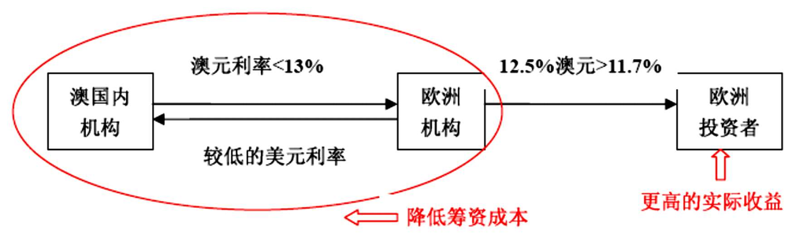

- 日本外币资产投资监管的互换套利
- 1984年底，澳元证券的高收益（假设为13%）引起了日本投资者的极大兴趣。
  - 但是日本当局规定日本机构在外币证券方面的投资不应超过其证券组合的10%。
  - 1985年初，上述10%的规定有所放宽，日本居民出于某些特殊原因发行的外币证券不属于10%的外币证券份额之内。
- 一些日本金融机构运用货币互换进行了套利：

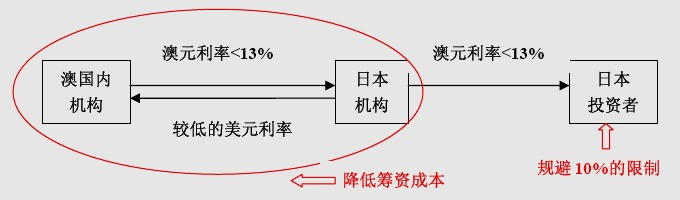

#### 运用互换进行风险管理

##### 用利率互换转换资产的利率属性

1. 固定利率→浮动利率：$$ \rightarrow^{固定利率资产} 交易者 {}^{浮动利率}\rightleftarrows^{固定利率} 对手方 $$
2. 浮动利率→固定利率：$$ \rightarrow^{浮动利率资产} 交易者 {}^{固定利率}\rightleftarrows^{浮动利率} 对手方 $$

##### 用利率互换转换负债的利率属性

1. 固定利率→浮动利率：$$ {}^{固定利率负债}\leftarrow 交易者 {}^{固定利率}\rightleftarrows^{浮动利率} 对手方 $$
2. 浮动利率→固定利率：$$ {}^{浮动利率负债} \leftarrow交易者 {}^{浮动利率}\rightleftarrows^{固定利率} 对手方 $$

##### 运用货币互换转换资产或负债的货币属性

1. 转换资产属性（A货币→B货币）：$$ \rightarrow^{A货币资产} 交易者 {}^{A货币}\rightleftarrows^{B货币} 对手方 $$
2. 转换负债属性（A货币→B货币）：$$ {}^{A货币负债}\leftarrow 交易者 {}^{A货币}\rightleftarrows^{B货币} 对手方 $$

##### 运用利率互换进行利率风险管理

- 作为利率敏感性资产，利率互换与利率远期、利率期货一样，经常被用于进行久期套期保值，管理利率风险。
- 利率互换的货币久期是其分解得到的固定利率债券与浮动利率债券货币久期之差，可用于利率风险管理。
- 在国外，利率互换协议最长可达30年，因此，利率互换是长期利率风险管理的重要工具之一

#### 运用互换构造新产品

##### 运用互换创造新产品

- 根据实际市场状况、投资者预期与需要的不同，利率互换可以与其他金融资产组合，创造出新产品。
  - 一笔固定利率的英国国债投资加上一份支付英镑固定利息、收入瑞士法郎固定利息的高信用等级货币互换，可以构造出一个近似的瑞士国债投资头寸。
- 案例8.6：一笔本金为A的浮动利率资产与一份名义本金为2A的利率互换空头组合，可以构造出一份合成的逆向浮动利率债券。
  - 反向浮动利率债券：
    - 当市场利率上升时，该债券的利息收入下降。
  - 运用利率互换构造反向浮动利率债券
    - 乙公司：
      - 拥有1份2年期，本金A，利率为1年期SHIBOR的浮动利率资产
      - 签订1份2年期，本金2A，每年交换1次的利率互换(r为固定利率)
    - $$ 甲银行{}^{2A*SHIBOR}\rightleftarrows^{2A*r} 乙公司 {}^{A*SHIBOR}\leftarrow $$
      - 净现金流：$A*(2r-SHIBOR)$

### 第九章 期权与期权市场

#### 定义与种类

##### 期权的定义

- 期权是买卖未来权利的合约，赋予其购买者（权利方）在规定期限内按双方约定的价格（行权价）购买或出售一定数量某种标的资产的权利。
- 协议要素
  - 买卖双方
    - 谁有“权利”谁就是多头
  - 约定的权利
  - 行权期限
  - 行权价（对比远期：交割价）
  - 交易数量
  - 期权价格（期权费）
- 在远期里面，$payoff = profit$，因为期初无成本；期权里面存在期权费，所以$ payoff = profit + option \space cost $
- 期权买者(多头)的权利划分：
  - 看涨期权（Call Option，认沽期权）：认购期权（或买权），赋予期权买者未来按约定价格购买标的资产的权利
  - 看跌期权（Put Option，认购期权）：认沽期权（或卖权），赋予期权买者未来按约定价格出售标的资产的权利
- 本质上是一种金融合约，是买卖双方关于未来某种权利的协议。
  - 多头：支付期权费后，只有权利，没有义务
  - 空头：收取期权费后，只有义务，没有权利
    - 存在违约风险，需要交保证金
- 买卖关系：

  \begin{matrix} \space & call & put \\ buyer & 按K价格买入的权利 & 按K价格卖出的权利 \\ seller & 按K价格卖出的义务 & 按K价格买入的义务 \end{matrix}
- 期权合约标的资产划分：P148
  - 股票期权
    - 一般为美式期权
    - 股票期权一般包含 100股
    - 行权价和期权费都以 1股股票为单位
  - ETF（Exchange-Traded Fund）期权
    - ETF在一级市场（发行市场）和二级市场（交易市场）都有交易
    - 国内最早：（上交所：上证50ETF期权2015.2.9）
      - 合约包含10000份上证50ETF
      - 行权价和期权费都以 1份上证50ETF为单位
  - 股价指数期权
    - 沪深300 & 中证1000
    - 欧式美式均有
    - 现金结算，乘数通常为 100
  - 期货期权
    - 合约到期日通常紧随着相应的期货期权到期日
    - 期权的权利方行权时，将从期权义务方处获得标的期货合约的相应头寸
      - （看涨期权为多头寸，看跌期权为空头寸），再加上*行权价格与行权日期货结算价格之间的差额*
  - 利率期权 只有场外 在其他金融工具中的利率期权
  - 信用期权
  - 货币期权（外汇期权）
  - 商品期权
  - 互换期权
  - 复合期权

##### 上证50ETF期权

- 标的
  - 上证50交易型开放式指数证券投资基金（“上证50ETF”）
- 类型
  - 认购期权和认沽期权
- 单位
  - 10000份上证50ETF
- 到期月份
  - 当月、下月及随后两个季月
- 价格
  - 至少9个（1个平值合约、4个虚值合约、4个实值合约）
    - 原先只有5个
    - 同时流通4个到期月的看涨、看跌期权，因此一天内至少流通$9 *4 *2 = 72$个期权
- 价格间距
  - 当前ETF价格为3元或以下K的间距为0.05元，3元至5元（含）为0.1元，5元至10元（含）为0.25元，10元至20元（含）为0.5元，20元至50元（含）为1元，50元至100元（含）为2.5元，100元以上为5元
- 行权方式
  - 到期日行权（欧式）
- 交割方式
  - 实物交割（业务规则另有规定的除外）
- 到期日 月份的第四个星期三（遇法定节假日顺延）
- 行权日 约到期日，行权指令提交时间为9:15-9:25，9:30-11:30，13:00-15:30
- 交收日 日次一交易日
- 交易时间
  - 上午 9:15-9:25，9:30-11:30（9:15-9:25为开盘集合竞价时间）
  - 下午 13:00-15:00（14:57-15:00为收盘集合竞价时间）
- 委托类型
  - 普通限价委托、市价剩余转限价委托、市价剩余撤销委托、全额即时限价委托、全额即时市价委托以及业务规则规定的其他委托类型
- 买卖类型
  - 买入开仓、买入平仓、卖出开仓、卖出平仓、备兑开仓、备兑平仓以及业务规则规定的其他买卖类型
- 最小报价单位
  - 0.0001元
- 申报单位
  - 1张或其整数倍
- 涨跌幅限制
  - 认购期权最大涨幅＝max {合约标的前收盘价×0.5%,min [（2×合约标的前收盘价－行权价格）,合约标的前收盘价]×10% }
  - 认购期权最大跌幅＝合约标的前收盘价×10%
  - 认沽期权最大涨幅＝max {行权价格×0.5%,min [（2×行权价格－合约标的前收盘价）,合约标的前收盘价]×10% }
  - 认沽期权最大跌幅＝合约标的前收盘价×10%
- 熔断机制
  - 竞价期间，期权合约盘中交易价格较最近参考价格涨跌幅度达到或者超过50%且价格涨跌绝对值达到或者超过5个最小报价单位时，期权合约进入3分钟的集合竞价交易阶段
- 初始保证金最低标准
  - 认购期权义务仓开仓保证金＝[合约前结算价+Max（12%×合约标的前收盘价-认购期权虚值，7%×合约标的前收盘价）]×合约单位
  - 认沽期权义务仓开仓保证金＝Min[合约前结算价+Max（12%×合约标的前收盘价-认沽期权虚值，7%×行权价格），行权价格]×合约单位
- 维持保证金最低标准
  - 认购期权义务仓维持保证金＝[合约结算价+Max（12%×合约标的收盘价-认购期权虚值，7%×合约标的收盘价）]×合约单位
  - 认沽期权义务仓维持保证金＝Min[合约结算价 +Max（12%×合标的收盘价-认沽期权虚值，7%×行权价格），行权价格]×合约单位

#### 期权市场

1. 合约单位
   - 所谓合约单位，也被称为交易单位或合约规模，就是一张期权合约所包含的标的资产数量。
     - 股票期权：100股股票
     - 股票指数期权：标的指数点数乘以每点100
     - 期货期权：一张标的期货合约
     - 外汇期权：视交易所不同和货币种类不同而不同
   - 50ETF期权：*10000*份上证50ETF
1. 行权价格
   - 期权合约中的行权价格由交易所事先设定。
     - 交易所准备上市某种期权合约时，首先根据该合约标的资产的最近收盘价，依据某一特定的形式来确定一个*中心行权价格*，然后再根据特定的幅度设定该中心价格的上下各若干级距（Intervals）的执行价格。
   - 在期权合约规格中，交易所通常只规定行权价格的级距。
     - 合约标的价格发生变化，导致已挂牌合约中的虚值或实值合约数量不足时，交易所将依据行权价格级距，依序加挂新行权价格的合约。
- 平值期权（In the money）、虚值期权（Out of the money）和平价期权（At the money）：市场惯例
  - 如果不考虑时间因素，期权的价值取决于标的资产市价（S）与行权价格（K）的差距。
  - 现实中，行权价最接近现货价的期权也可以视为平价期权
  - 看涨期权
    - $S>K$ 时，实值期权
    - $S=K$ 时，平价期权
    - $S<K$ 时，虚值期权
    - 行权价K越低，看涨期权越值钱
      - 实值期权永远更贵
  - 看跌期权
    - $K>S$ 时，实值期权
    - $K=S$ 时，平价期权
    - $K<S$ 时，虚值期权
    - 行权价K越高，看跌期权越值钱
      - 实值期权永远更贵
1. 除权除息
   - 国内的场外期权受红利保护：如果公司派发现金红利，除权日后行权价格要相应调整。
   - 发放红利之后股票除权：$S^{'}_{T} = S_{T}-I_{T}$
   - 境外交易所流通的期权通常不受红利保护，但在股票分割或送红股（用股票发红利）时要调整（国外的惯例）
     - 在n对m（即m股股票分割为n股）股票分割之后，行权价格降为原来行权价格的m/n，每一期权合约所包含的标的资产数量上升到原来的n/m倍。
       - “10送10”：$ K' = K*\frac{10}{10+10} $
       - m股股票分割为n股:$ K' = K*\frac{m}{n} $
     - 发放n%的股票红利等同于$100+n$对0的分割。
   - 上证50ETF期权受红利保护(国内的惯例)
     - 原则：合约标的总价值不变；行权总价值不变
     - $K^{'}_{T} = K_{T}-I_{T} $
     - P155：上交所除权除息规定（课外阅读，公式不作要求）
1. 行权方式
   - 行权的比例要比期货交割比例高得多
     - 期货一般选择平仓，而不是交割
   - 现货期权的行权：
     - 直接以行权价对标的资产进行实际的交收。
   - 指数期权的行权：
     - 按照行权价与期权行权日当天交易结束时的市场价格之差以现金进行结算。
   - 期货期权的行权：
     - 权利方行权时，将从期权义务方处获得标的期货合约的相应头寸，再加上行权价与期货结算价之间的现金差额。
   - 50ETF期权：实物交割

#### 期权交易机制

1. 持仓限额和行权限额
   - 头寸限额（Position Limit）：每个投资者在市场的一方所能持有的期权头寸的最大限额
     - 看涨多头/看跌空头
     - 看涨空头/看跌多头
   - 行权限额（Exercise Limit）：一个期权权利方在规定的一段时间内所能行权的期权合约的最大限额
   - 计算标准：合约数量/合约总金额
   - 交易所规定期货期权中期权头寸与相应的期货头寸合并计算
     - 如果都认为标的资产会涨，期货多头也认为标的资产会涨
   - P158：上证50ETF期权持仓限额（课外阅读，不作为考试要求）
1. 买卖指令和委托指令
   - 交易指令：上交所
     - 买入建仓，即买入一个期权，建立一个新头寸；
     - 卖出建仓，即卖出一个期权，建立一个新头寸；
     - 买入平仓，即买入一个期权，对冲原有的空头头寸；
     - 卖出平仓，即卖出一个期权，对冲原有的多头头寸；
     - 备兑开仓，是指投资者在持有足额标的证券的基础上，卖出相应数量的认购期权合约。
       - 已经有现货ETF，可以把现货锁定之后卖空期权
     - 备兑平仓，是投资者持有备兑持仓头寸时，申请买入相应期权将备兑头寸平仓的指令
       - 已经有抵押的现货，所以空头的违约风险较低
   - 买卖对未平仓合约的影响
     - 和期货一样
   - P158：上交所委托指令（课外阅读，不作为考试要求）
1. 保证金制度
   - 期权多头
     - 交了期权费，无需缴纳保证金
       - 只有权利，没有义务，不存在违约可能性
   - 期权空头
     - 类似期货保证金，分为初始保证金和维持保证金
     - 具体保证金取决于期权种类和市场状况
       - 看涨空头：抵押品为ETF现货
       - 看跌空头：抵押品为K现金
   - 100%保证金要求： Covered Options
     - 100%标的资产S（call）或100%资金K（put）
   - 非100%保证金（eg. 国外股票期权）
     - 初始保证金：两式取较大者$max(m_1,m_2)$
       - 期权的期权费收入加上期权标的资产价值的20%减去期权处于虚值状态的数额（如果有这一项的话）
         - $m_1 = 期权费 + S_t*20\% - 虚值部分 $
         - 为什么扣除的是虚值：虚值期权的空头违约风险较低，不需要太高保证金
       - 期权的期权费收入加上标的资产价值（看涨期权）或执行价格（看跌期权）的10%
         - $ m_2 = 期权费+ 10\%*max(S_{t},K) $
       - 保证金为二者取max的结果，因为虚值有可能特别大，出现保证金为负
     - 维持保证金
   - 保证金：上证50ETF期权
     - $认购期权义务仓开仓保证金＝[合约前结算价+Max(12\%×合约标的前收盘价-认购期权虚值,7\%×合约标的前收盘价)]×合约单位$
     - $认沽期权义务仓开仓保证金＝Min[合约前结算价+Max(12\%×合约标的前收盘价-认沽期权虚值，7\%×行权价),行权价]×合约单位$
       - 保证金为K时，为100%安全保证金
     - 虚值：
       - $认购期权虚值＝Max（行权价-合约标的前收盘价，0）$
       - $认沽期权虚值＝Max（合约标的前收盘价-行权价，0）$
   - 期权头寸的保证金

#### 期权与其他衍生产品的区别与联系

##### 期权 & 期货

1. 权利&义务
   - 期权：多方有权利无义务；空方有义务而无权利
   - 期货：多空双方都有权利和义务
2. 标准化
3. 盈亏风险
   - 对于期货交易， 空方的亏损可能是无限的， 盈利则可能是有限的； 多方最大的亏损可能是标的资产价格跌至零,盈利可能是无限的
4. 保证金
   - 期货交易的买卖双方都需交纳保证金
   - 期权的权利方则无须交纳保证金
5. 套期保值

##### 期权 & 权证（Warrants）

- 权证是发行人与持有者之间的一种契约，其发行人可以是上市公司，也可以是上市公司股东或投资银行等第三者。
  - 权证允许持有人有权在约定的时间（行权时间），按约定的价格（行权价）向发行人购买或出售一定数量的标的资产。
- 分类：
  - 认购权证 & 认沽权证
  - 股本权证 & 备兑权证（衍生权证）
    - 股本权证：上市公司自己发行
      - 期限通常较长
      - 持有者执行权证时，会导致股本变动
    - 备兑权证：独立的第三方发行
      - 还可能以股指、一揽子股票或其他资产作为标的
    - 不同：
      - 发行目的不同
      - 发行人不同
      - 是否影响总股本
    - 多为备兑权证
- 股票期权 & 股本权证
  - 发行环节
  - 是否有限
  - 影响总股本
- 股票期权 & 备兑权证
  - 发行环节
  - 是否有限
- 2011年股权分置改革完成后，权证在中国市场上停止流通

##### 雇员股票期权

1. 存在锁定期，锁定期内不能行权
2. 如果锁定期内离职，则直接作废
3. 如果在行权期内为虚值，则不行权；如果为实权，则立刻提前行权
4. 不能转卖期权
5. 公司通过发行新股来行权

##### 内嵌期权

- 内嵌期权，是指在普通的金融产品中加上一个具有期权性质的条款，使得该产品称为普通金融工具和期权的一个组合。
  - 可转债
    - 看涨期权多头
    - 根据债券面值转股
  - 可赎回债
    - 看涨期权空头，市场价值超过行权价的时候公司会行权赎回，是利率的看跌期权
  - 可回售债
    - 看跌期权多头，市场价值小于行权价的时候客户会行权赎回，是利率的看涨期权
  - 结构性产品(缝合怪)
    - eg. 顺丰转债的基本条款
      - 公司债多头
      - 转股（投资者的期权）
      - 赎回（公司的期权）
      - 回售（投资者的期权）
      - 下调转股价（公司的期权）
        - 在一定条件下调整转股价格的期权
        - 下调转股价格的条件比回售更宽松，所以下调价格可以防止投资者回售
    - 对于投资者而言：
      - 可转换债券=普通债券+转股权-赎回权+回售权+转股价调低权

### 第十章 期权的回报与价格分析

#### 期权的回报与盈亏分布

[figure not shown]

```python
import matplotlib.pyplot as plt
import numpy as np
S_T = np.arange(start=0, stop=100,step=0.1)
K = 50
c,p = 10,10
call_long = np.where(S_T>K,S_T-K,0)
put_long = np.where(S_T<K,K-S_T,0)
call_short = np.where(S_T>K,K-S_T,0)
put_short = np.where(S_T<K,S_T-K,0)

ax_1 = plt.subplot(2,2,1)
ax_2 = plt.subplot(2,2,2)
ax_3 = plt.subplot(2,2,3)
ax_4 = plt.subplot(2,2,4)

ax_1.plot(S_T,call_long,S_T,call_long-c)
ax_1.set_title('看涨多头:回报&盈亏')
ax_2.plot(S_T,put_long,S_T,put_long-p)
ax_2.set_title('看跌多头:回报&盈亏')
ax_3.plot(S_T,call_short,S_T,call_short+c)
ax_3.set_title('看涨空头:回报&盈亏')
ax_4.plot(S_T,put_long,S_T,put_long+p)
ax_4.set_title('看跌空头:回报&盈亏')
```

- 以上四幅图并没有给出回报和盈亏对应的概率分布，容易让人误解期权多空双方在盈亏上严重不对称。实际上期权多头的特征是“大概率亏期权费，小概率获利”；期权空头则是“大概率赚期权费，小概率亏损”。
  - 在一个公平市场上，期权多空双方的期望损益是相对称的。
- 只要在卖出期权后，能有效地对冲小概率亏损的风险，仍然是可以充当期权空方的，如专业的金融机构。但如果单纯卖出期权，就是在冒小概率的巨亏风险，是高风险的行为。

\begin{matrix} position & payoff & profit\\ call_{long} & max(S_{T}-K,0) & max(S_{T}-K,0)-c_{t} \\ put_{long} & max(K-S_{T},0) & max(K-S_{T},0)-p_{t} \\ call_{short} & -max(S_{T}-K,0) & -max(S_{T}-K,0)+c_{t} \\ put_{short} & -max(K-S_{T},0) & -max(K-S_{T},0)+p_{t} \\ \end{matrix}

#### 期权价格的特性

##### 期权价格：内在价值与时间价值

- 期权价格（或价值） =内在价值 +时间价值
  - 内在价值（Intrinsic Value）是指在*不考虑标的资产价格波动*的情况下，期权条款*赋予期权多头的最高价值*；（或有回报的最大值）
  - 时间价值(Time Value）是指在期权剩余期限内，*标的资产价格的波动*为期权多头带来收益的可能性所*隐含的价值*（波动带来的价值）。
    - 时间价值会受内在价值的影响，但内在价值不受时间价值的影响。

##### 内在价值与平值点(本书定义与市场不同)

- 市场惯例：将当前的标的资产价格$S_{t}$作为所有期权的平值点，并未区分美式期权与欧式期权的不同特点。
  - call: $max(S_{T}-K,0)$
  - put: $max(K-S_{T},0)$
  - 平值点：$ K_{ATM} = S_{T} $
  - 为什么不用市场惯例？
    - 为了保证期权的时间价值不会小于0，所有期权价格的下限就是其内在价值，而且期权的时间价值都在平值点最大
1. 欧式看涨期权的内在价值
   - 不考虑时间价值， 欧式看跌期权合约与远期合约空头的唯一区别就是前者只有权利没有义务
     - $max(-f,0) = max[(F-K)e^{e(T-t)},0] $
       - 内在价值为负时，可以选择不行权
     - 此时的平值点(At The Money)：$ K_{ATM} = F $(和红利支付方式有关)
2. 欧式看跌期权的内在价值

##### 实值期权、平值期权与虚值期权

- 平值期权（At the Money, ATM）
  - 平值点（$K_{ATM}$）就是期权内在价值由正值变化到零的行权价格的临界点
- 实值期权（In the Money, ITM）
  - Call：行权价格<平值点
  - Put:行权价格>平值点
- 虚值期权（Out of the Money, OTM）
  - Call：行权价格>平值点
  - Put：行权价格<平值点
- 虚值和平值期权的内在价值为零，其全部价值都体现为时间价值；实值期权具有正的内在价值。

##### 期权的时间价值

- 期权的时间价值是指在期权剩余期限内，标的资产价格的波动为期权多头带来收益的可能性所隐含的价值（波动带来的价值）。
  - 期权的时间价值是基于期权多头权利义务不对称这一特性，在期权到期前，标的资产价格的变化可能给期权多头带来的收益的一种反映。 书对期权内在价值的定义，期权的时间价值一定大于等于0。
- 影响期权时间价值的因素：
  - $T-t$:其他条件相同的情况下，一般来说，距离期权到期时间越长，期权的时间价值越大，对美式期权来说尤其如此。
  - $\sigma$:其他条件相同的情况下，标的资产价格的变化（波动）越大，期权的时间价值就越大。
  - 在值程度：按本书的平值点和在值程度定义，*平值期权*（在值程度为0,$K=K_{ATM}$）的时间价值最大，实值和虚值期权的时间价值则随着实值和虚值程度的提高而逐渐递减。

##### 期权价格的影响因素

- 标的资产的市场价格
  - 希腊字母：$\Delta = \frac{\partial V_{t}}{\partial S_{t}}$
  - $S_{t}$越大，$c^{E}_{t}$ 越大， $p^{E}_{t}$越小
- 行权价格
  - $K$越大，$c_{t}$ 越小， $p^{E}_{t}$越大
- 剩余期限
  - $T-t$越大，$c^{A}_{t}$ 越小（行权时间区间更大），一般而言 $c^{E}_{t}$ 越小
- 标的资产价格的波动率
  - $\sigma$越大，$c_{t}$、$p^{E}_{t}$越大
  - 如果没有波动，则期权就没有时间价值
    - 此时看涨期权仍有行权价值，而看跌期权价值为0
- 无风险利率 （理论上不能确定）
  - 利率r越高，标的资产的预期收益率也越高，这意味着对应于标的资产现在特定的市价$S_{t}$，未来预期价格 E(S*{T})越高。（明显） 由于贴现率r越髙，未来同样预期回报$(K-S*{T})^{+}$的现值就越低。（不明显）
  - 看跌期权价值 $p^{E}_{t}$ 会降低，看涨期权价值 $c^{E}_{t}$ 会上升
- 标的资产的收益

##### 不提前行权无红利资产美式看涨期权的合理性

- 对于无红利资产美式看涨期权来说，$T_{0}$ 时刻提前行权对权利方的影响：
  - 多头需提前支付行权价，因此要多损失行权价的利息 $K*e^{r(T-T_{0})}$；
  - 多头提前获得标的资产，但该标的资产没有红利，因此*提前获得标的资产并没有好处* $S_{T_{0}}*e^{\delta(T-T_{0})}=0$；
  - 提前行权意味着失去了*期权的时间价值*，而时间价值永远大于等于零。
- 提前行权无红利资产的美式看涨期权是不明智的。
  - 对于无红利资产的美式看涨期权，如果预判未来资产价格可能下跌，最优的选择是*卖掉期权*，而不是提前行权。
    - 只有如同雇员股票期权这种无法转卖的期权，才会在实值的时候提前行权
  - 在其他条件相同的情况下，无红利资产美式看涨期权和欧式看涨期权实际上是等价的，它们的价值是相同的，其内在价值和时间价值都相等。

##### 提前行权无红利资产美式看跌期权的合理性

- 对于无红利资产美式Put来说，$T_{0}$ 时刻提前行权对权利方的影响：
  - 多头提前得到行权价，因此可以获得行权价的利息 $K*e^{r(T-T_{0})}>0$；
  - 多头提前支付标的资产，但该标的资产没有红利，因此提前行权并没有损失红利 $S_{T_{0}}*e^{\delta(T-T_{0})}=0$；
  - 提前行权意味着失去了期权的时间价值。
- 是否提前行权无红利资产的美式看跌期权，主要取决于期权的实值程度、无风险利率水平等因素。
  - 一般来说，只有当实值程度较高(可以抵消损失的时间价值)、利率较高时，提前行权无红利资产美式看跌期权才可能是有利的。

##### 提前行权有红利资产美式看涨期权的合理性

- 提前行权的好处：
  - 获得红利
- 坏处：
  - 提前支付行权价格，会损失行权价的利息
  - 浪费期权的时间价值
- 如果红利小于行权价格的利息$I<K*e^{r(T-T_{0})}$，那么提前行权是不合理的；但如果红利大于行权价格的利息，那么提前行权就*有可能*是合理的。
  - 一般来说，只有当实值程度较高、红利较高、利率较低时，提前行权有红利资产美式看涨期权才可能是有利的。 行权的得到的红利I应当要弥补利息 $K*e^{r(T-T_{0})}$ 与时间价值，才要提前行权

##### 提前执行有红利资产美式看跌期权的合理性

- 提前行权有红利资产的美式看跌期权意味着自己放弃标的资产的红利
  - 与无红利资产的美式看跌期权相比，有红利资产美式看跌期权提前行权的可能性减小，但仍无法完全排除提前行权的可能性

##### 期权价格的上限

- 欧式看涨： \begin{cases} c^{E}_{t} \leq S_{t} , 无红利资产 \\ c^{E}_{t} \leq S_{t} -I ， 有红利资产 \end{cases}
- 美式看涨： $$c^{A}_{t} \leq S_{t}$$
- 对于看涨期权，回报的最大值就是得到1单位标的资产（去除红利）
- 欧式看跌： \begin{cases} c^{E}_{t} \leq K*e^{r(T-t)} , 无红利资产 \\ c^{E}_{t} \leq K*e^{r(T-t)} ， 有红利资产 \end{cases}
- 美式看跌 $$c^{A}_{t} \leq K$$
- 对于看跌期权，回报的最大值就是得到K单位现金（加上持有资产的红利）
- 期权价格的下限：
  - 按照本书内在价值的定义，由于期权的时间价值一定大于0，因此期权价格一定大于等于期权的内在价值，即*期权的内在价值*就是期权的下限。

##### 无红利欧式看涨期权 & 看跌期权的价值曲线

[figure not shown]

##### 看涨-看跌平价公式（PCP）

1：欧式看涨和看跌期权的时间价值是相等的（按照本书的内在价值定义）

2：对于欧式平值期权（K=F）来说，它们的内在价值都等于0，因此，欧式平值看涨期权和看跌期权价格相等，它们的时间价值也相等。

##### PCP公式的内涵和运用P190：

- 价格的计算
  - 无模型定价（model-free，不受定价模型的假设约束）：$ c^{E}_{t} = p^{E}_{t} S_{t} -K*e^{r(T-t)} $
- 金融产品
  - 欧式看跌、风险资产、无风险资产复制欧式看涨：$ c^{E}_{t} = p^{E}_{t} S_{t} -K*e^{r(T-t)} $
- 套利机会
  - $$c^{E}_{t}+K*e^{r(T-t)} = p^{E}_{t} + S_{t}$$
  - 若等号不成立，则存在套利机会

### 第十一章 B-S-M期权定价模型

##### PDE方法的思路

1. 假设股价服从几何布朗运动：$d(S_{t}) = S_{t}(\mu dt + \sigma dW_{t}) $
   - $W_{t}$ 为维纳过程（标准布朗运动）
2. 利用$it\hat{o}$引理，得到期权价格的SDE:$dV_{t} = (\frac{\partial V_{t}}{\partial t}+\mu S_{t}\frac{\partial V_{t}}{\partial S_{t}}+ \frac{1}{2}\frac{\partial^{2}V_{t}}{\partial S_{t}^{2}})dt+\sigma S_{t} \frac{\partial V_{t}}{\partial S_{t}}dW_{t} $

#### 股票价格的变化过程

##### Markov过程

- 马尔可夫随机过程，是指只有变量的当前值才与未来的预测有关，变量过去的历史和变量从过去到现在的演变方式与未来的预测无关
  - t时刻的信息能够真正影响t+1时刻的数学期望 $E(X_{n+1} = x|X_{1\~n}=...) = E(X_{n+1} = x|X_{n}=x) $

##### 标准布朗运动(维纳过程)

- 布朗运动：$ dS_{t} = S_{t}*e^{\mu t \sigma W_{t}} $
  - $W_{t}$ 为标准布朗运动
- 布朗运动的四大特征：
  - 初始值为零 $ W_{0}=0 $
  - 独立平稳增量：对于任何两个不重合的时间间隔Δt， Δz的值相互独立 $Cov(P(W_{t+s}-W_{t}=...),P(W_{t}=...))=0$
  - 独立同分布：在任意小的时间间隔 Δt内，增量均服从均值为零、方差等于时间长度的正态分布 $W_{\Delta t} \sim N(0,\Delta t)$
- 使用布朗运动 P199
  - 分布：经验事实证明，股票价格的连续复利收益率*近似地服从正态分布*（P204图11.1）
  - 可以证明，标准布朗运动（维纳过程）是一个*马尔可夫随机过程*，从而与弱式EMH相符
  - 布朗运动（维纳过程）在数学上*对时间处处不可导*和二次变分（Quadratic Variation,可以用方差来类比）不为零的性质，与股票收益率在时间上存在转折尖点等性质也是相符的

##### 普通布朗运动：标准布朗运动的扩展（一般化的维纳过程）

- 普通布朗运动的变量 $x_t = \mu dt + \sigma dz_{t}$ 是关于时间和 $dz_t$ 的动态过程，$\mu$ 和 $\sigma$ 均为常数
  - $\mu dt$为确定项，漂移率 $\mu$ 意味着x的漂移速度是每单位时间为 $\mu$；
  - $\sigma dz_{t}$ 是随机项，代表着对 $x_t$ 的时间趋势过程所添加的噪声，使变量$x_t$围绕着确定趋势上下随机波动，且这种噪声是由维纳过程的 $\sigma$ 倍给出的， $\sigma^{2}$ 称为方差率，$\sigma$ 称为波动率。

##### $it\hat{o}$过程

- 最常见的一类伊藤过程，是将at和bt设定为变量xt和时间t的确定性函数：$$ dx_t = \mu(x_{t},t) dt + \sigma(x_{t},t) dz_t $$
  - $\mu(x_{t},t)$ 与 $\sigma(x_{t},t)$ 为关于t的可料过程
  - 称之为“扩散过程”（diffusion process）

##### 几何布朗运动

布朗运动（ Geometric Brownian Motion）:$$ dS_{t} = S_{t}(\mu dt + \sigma dz_t) $$ ，μ (漂移率)和σ (波动率)均为常数 这是一个漂移项为$μSt$，方差项为$σ^2 S^2_t$的伊藤（扩散）过程 用几何布朗运动来描述股票价格的随机过程。

- 为什么不用普通布朗运动？
  1. 可以避免股票价格为负从而与有限责任相矛盾的问题
  2. 几何布朗运动意味着股票连续复利收益率服从正态分布，这与实际较为吻合 复利收益率（不一定为年化收益率）：$$(lnS_{T}-lnS_{t}) \sim N[(\mu-\frac{1}{2}\sigma^{2})(T-t),(\sigma \sqrt{T-t})^{2}] $$
  3. 股票价格的对数服从普通布朗运动，特定时刻的股票价格$S_T$服从对数正态分布（取对数之后为正态） $$E(S_{T}) = S_{t}*e^{\mu(T-t)}$$ $$Var(S_{T}) = S_{t}^{2}(e^{\sigma^{2}(T-t)}-1)e^{\mu(T-t)}$$ ， μ是Δt时间内股票价格*百分比*的年化预期收益率(对数收益率则是$\mu - \frac{1}{2}\sigma^{2}$)

##### 伊藤引理($it\hat{o}\space lemma$)

- 伊藤引理的推导
  - 我们知道 $x_t$遵循伊藤过程，通过Itô-Doeblin引理可以推导出 $f(x_t, t)$遵循的随机过程。
    1. 泰勒展开：$f(x_t, t) = \frac{\partial f}{\partial t}dt + \frac{\partial f}{\partial x_{t}} + \frac{1}{2} \frac{\partial^{2} f}{\partial x_t^{2}}(dx_{t})^{2} ....$
    2. 注意到$d(x_{t})^{2} = \sigma^{2}dt $，存在dt的同阶无穷小，所以不应该舍去这一项
- 伊藤引理的应用(对于 $dS_{t} = S_{t}(\mu dt + \sigma dz_{t}) $):
  1. 连续复利收益率 $lnS_t$ 的SDE:$ d(lnS_{t}) = \frac{1}{S_{t}} dS_{t} - \frac{1}{2} (dS_t)^{2} = (\mu - \frac{1}{2} \sigma^{2})dt +\sigma dz_t $
  2. 远期价格 $F_t = S_{t}*e^{r(T-t)}$的SDE: $dF_t = F_{t}[(\mu - r)dt + \sigma dz_t] $

衍生产品价格是标的资产价格和时间的函数，因此Itô-Doeblin引理在衍生产品分析中扮演重要的角色。

##### 百分比收益率 & 对数收益率

- 在一个很短的瞬间Δt，股票价格的百分比收益率服从：$ \frac{\Delta S}{S} = \mu \Delta t+ \sigma * \epsilon \sqrt{\Delta t} $
  - 即在很短的时间内，百分比收益率具有正态分布特征，其均值为$μΔt$，方差为$σ^2 Δt$。
- 但由于较长时间内的百分比毛收益率为每个短时间百分比收益率的乘积，而正态分布变量的乘积并不服从正态分布，所以几何布朗运动只意味着短时间内的百分比收益率服从正态分布，在长时期内其正态分布的性质不再存在。
- 而较长时间的连续复利收益率为每个短时间连续复利收益率之和，独立正态分布变量之和仍为正态分布，因此连续复利收益率始终服从正态分布。
  - $d(lnS_{t}) = (\mu - \frac{1}{2}\sigma^{2})dt + \sigma *dz_{t}$
- 短时间间隔Δt内百分比收益率的年化期望值为μ，而连续复利收益率的年化期望 值仅为(μ−σ2/2)，股票价格的波动越大，两者的差异也越大
- T时刻股票价格ST的期望值：
  - 由于$e^x$函数是非线性的，$E(e^{x}) \neq e^{E(x)}$
  - 因此股票价格的期望值$E_{P}[S_T]=S_t*e^{μ(T-t)}$并不意味着年化连续复利收益率的期望值为μ

##### 鞅(Martingale)

- 定义：$$ E(X_{T}|F_{t}) = X_{t} $$
- 判断方法：$$ dX_{t} = \sigma(X_{t},t)dz_{t} + 0dt $$

#### BSM期权定价公式（无风险定价法）

##### 假设

- 不存在无风险套利机会；(无套利)
- 允许卖空标的股票；
- 没有交易费用和税收
- 证券交易是连续的，价格变动也是连续的；
- 所有证券都完全可分；（可复制）
- 股票价格遵循几何布朗运动，即μ和σ为常数；
- 在衍生产品有效期内，无风险连续复利利率r为常数；
- 在衍生产品有效期内标的股票无红利。（股价连续，无“跳跃”现象）

##### B-S的PDE

1. $f$为依赖于$S_{t}$的衍生品价格，根据伊藤引理，可得：$$ df_{t} = \frac{\partial f }{\partial t}dt + \frac{\partial f}{\partial S}dS +\frac{1}{2}\frac{\partial^{2} f}{\partial S^{2}}(dS)^{2} $$
2. 整理可得：$$ df_{t} = (\frac{\partial f }{\partial t}+ \frac{1}{2}\sigma^{2}S^{2}\frac{\partial^{2} f}{\partial S^{2}})dt + \frac{\partial f}{\partial S}dS $$
3. 由于$dS$中存在随机过程$dz_{t}$，因此考虑使用无风险组合$\pi_{t} = f_{t} - \frac{\partial f}{\partial S}*S$来对冲风险
4. 可以写出$pi_{t}$的SDE:$ (\frac{\partial f }{\partial t}+ \frac{1}{2}\sigma^{2}S^{2}\frac{\partial^{2} f}{\partial S^{2}})dt $
5. 由于$pi_{t}$已经成为无风险组合，其收益率为：$ d\pi_{t} = \pi_{t}*r dt $
6. 因此，可以列出方程：$$ \frac{\partial f }{\partial t}+ \frac{1}{2}\sigma^{2}*S^{2}*\frac{\partial^{2} f}{\partial S^{2}} + r*S*\frac{\partial f}{\partial S} - r*f =0 $$
- 在一定的边界条件下求解BSM偏微分方程，就可以得到ft所满足的表达式，也就是衍生证券的定价公式。
  - 注：对于不同衍生品而言，其主要的边界条件就是到期回报。虽然同一标的的衍生证券所满足的偏微分方程相同，但不同边界条件得到的解是不同的。
  - 注：当$S_t$和t变化时，$\frac{\partial f}{\partial S}$ 的值也会变化，因此上述组合的价值并不是永远无风险的，它只是在一个很短的时间间隔 Δt中才是无风险的。

##### 风险中性定价原理

- 观察BSM偏微分方程可以发现，受制于主观风险收益偏好的标的证券预期收益率μ并未包括在衍生证券的价值决定公式中。这意味着，无论风险收益偏好状态如何，都不会对f的值产生影响。
  - $\mu$体现了投资者的风险爱好程度
- 因此我们可以作出一个可以大大简化我们工作的技术假定：在对衍生证券定价时，所有投资者都是风险中性的。

##### 风险中性世界（Q测度）

- 风险中性世界中，投资者只关心资产的预期回报（Expected Payoff），而不关心该回报的风险。这样预期回报相等的资产，其目前的价格都相等。
- 对于到期回报为1的贴现式债券而言：$E_{Q}(1*B_{T}|\Bbb{F}_{t}) = e^{-r(T-t)}$
- 对于到期预期回报为$E(S_T)$的资产而言，其价格为$E_{Q}(S_{T}|\Bbb{F}_{t}) = E_{Q}(S_T)*e^{-r(T-t)} $
- 在所有投资者都是风险中性的条件下（有时我们称之为进入了一个“风险中性世界”）：
  - 所有可交易证券的漂移率(预期收益率)都等于无风险利率r。
  - 所有现金流的期望值都应该使用无风险利率r进行贴现。
  - 这就是风险中性定价原理。
- 注：风险中性定价原理来源于BSM偏微分方程中没有μ的存在。
  - 而偏微分方程是在无套利条件下，运用*可交易*的证券复制出无风险组合得到的，因此，*只有可交易证券*在风险中性世界中的预期收益率才为无风险利率 r。
- 必须强调的是：风险中性定价仅仅是为了衍生品定价而做出的技术假定，并不意味着我们真的认为市场投资者是风险中性的，但通过这种假定得到的定价结果，不仅适用于风险中性的情形，也适用于投资者厌恶风险的所有情形。
- 运用风险中性定价法的条件：无套利和可复制

##### 无红利资产欧式看涨期权的定价公式

1. 已知T时刻payof：$X_{T} = max(S_{T}-K,0)$
2. 因此t时刻的欧式看涨期权价值$c^{E}_{t}$即为：$$ c^{E}_{t} = e^{-r(T-t)}E_{Q}(X_{T}|\Bbb{F}_{t}) $$
3. 已知$S_{T} = S_{t}*e^{\mu*(T-t)+\sigma*(W_{T}-W_{t})}$
4. 构造风险中性测度：$\tilde{W}_{t} = W_{t}+ \frac{\mu - r + \frac{1}{2}\sigma^{2}}{\sigma}$
5. 代入风险中性期望：

   \begin{aligned} E_{Q}(X_{T}|\Bbb{F}_{t}) &= E_{Q}(max(S_{T}-K,0)|\Bbb{F}_{t}) \\ &= E_{Q}(max(S_{t}*e^{\mu*(T-t)+\sigma*(W_{T}-W_{t})}-K,0)|\Bbb{F}_{t}) \\ & = E_{Q}(max(S_{t}* e^{(r-\frac{1}{2}\sigma^{2}) * (T-t)+\sigma*(\tilde{W}_{T}-\tilde{W}_{t})}-K,0)|\Bbb{F}_{t}) \\ \end{aligned}
6. 确定积分界限：令$S_{t}* e^{(r-\frac{1}{2}\sigma^{2}) * (T-t)+\sigma*(\tilde{W}_{T}-\tilde{W}_{t})}-K \geq 0$

   可得：$ \frac{\tilde{W}_{T}-\tilde{W}_{t}}{ \sqrt{T-t}} \geq - \frac{ln(\frac{S_{t}}{K}+(r-\sigma^{2}))}{\sigma \sqrt{T-t}} $

   设 $y = \frac{\tilde{W}_{T}-\tilde{W}_{t}}{ \sqrt{T-t}} $,$ d_{2} = \frac{ln(\frac{S_{t}}{K}+(r-\sigma^{2}))}{\sigma \sqrt{T-t}} $,$d_{1} = d_{2}+\sigma\sqrt{T-t} = \frac{ln(\frac{S_{t}}{K}+(r+\sigma^{2}))}{\sigma \sqrt{T-t}}$
7. 积分求期望：

   \begin{aligned} E_{Q}(X_{T}|\Bbb{F}_{t})&= \int_{-d_{2}}^{+\infty} S_{t} * e^{(r-\frac{1}{2}\sigma^{2}) * (T-t)+\sigma*\sqrt{T-t}*y} *\frac{1}{\sqrt{2\pi}} *e^{-\frac{y^{2}}{2}} dy - \int_{-d_{2}}^{+\infty} K *\frac{1}{\sqrt{2\pi}} *e^{-\frac{y^{2}}{2}} dy\\ & = S_{t}* e^{r(T-t)} * \int_{-d_{2}}^{+\infty} \frac{1}{\sqrt{2\pi}}* e^{-\frac{y^{2}}{2}+\sigma* \sqrt{T-t}*y-\frac{1}{2} *\sigma^{2}} dy -K *\Phi(d_2) \\ &=S_{t}* e^{r(T-t)} * \int_{-d_{2}-\sigma*\sqrt{T-t}}^{+\infty} \frac{1}{\sqrt{2\pi}}* e^{-\frac{y^{2}}{2}+\sigma* \sqrt{T-t}*y-\frac{1}{2} *\sigma^{2}}d(y+ \sigma *\sqrt{T-t})-K *\Phi(d_2)\\ &= S_{t}* e^{r(T-t)} \Phi(d_1) - K *\Phi(d_2) \end{aligned}
8. 因此可得无红利资产欧式看涨期权的定价公式：$$c^{E}_{t} = S_{t}* \Phi(d_1) - K*e^{-r(T-t)} *\Phi(d_2) $$
   - $\Phi(X)$表示标准正态分布的概率分布函数(CDF)

#### 理解B-S-M期权定价公式

##### 复制策略

- 我们可以用股票和负债复制期权。
  - 可以证明$\Phi(d_1) = \frac{\partial V}{\partial S}$,它是构造无风险组合$\Pi$时的Δ，是复制投资组合中股票的数量，$S_t*\Phi(d_1)$就是股票的市值
  - 而 $K*e^{-r(T-t)}\Phi(d_2)$则是复制交易策略中负债的价值。
- 由于主要参数都是时变的，因此这种复制策略是动态复制策略，必须不断调整 相关头寸数量
- 证明：$\frac{\partial V}{\partial S} = \Phi(d_{1})$:
  - $ V_{t} =S_{t}* \Phi(d_1) - K*e^{-r(T-t)} *\Phi(d_2) $
  - \begin{aligned} \frac{\partial V}{\partial S} &= \frac{\partial S* \Phi(d_1)- K*e^{-r(T-t)} *\Phi(d_2)}{\partial S} \\ &= \Phi(d_1) + S*\phi(d_1) * \frac{\partial (d_1)}{\partial S} - K*e^{-r(T-t)} *\phi(d_2) * \frac{\partial (d_2)}{\partial S} \\ &= \Phi(d_1) \end{aligned}
  - 注意到：$ S*\phi(d_1)= K*e^{-r(T-t)} *\phi(d_2)$,$ \frac{\partial (d_1)}{\partial S} = \frac{\partial (d_2)}{\partial S} $

##### 风险中性概率

- 可以证明：$N(d_2)$是风险中性测度下$S_T>K$的概率，即欧式看涨期权被行权的*风险中性概率*，因此，$K*e^{-r(T-t)}N(d_2)$可以看成预期行权所需支付现金的现值。
- 而$E_{Q}(S_{T}|\Bbb{F}_{t}) = E(S_T)*e^{-r(T-t)}$则是在风险中性测度下，一个$S_{t}$如果$S_T > K$就等于$S_{T}$，否则就等于0的变量的期望值， $S_t*N (d_1)$则是这个期望值的贴现值，可以看成期权持有者预期行权所得回报的现值。
- 因此，整个看涨期权定价公式就是在风险中性测度下期权未来期望回报的现值

##### 欧式期权的分解：数字期权（cash or nothing option） & 资产赢或输期权（asset or nothing）

- 从金融工程的角度来看，欧式看涨期权可以分拆成或有资产看涨期权（Assetor-nothing Call Option）多头和 K份或有现金看涨期权（Cash-or-nothing Call Option）空头之和
  - $c^{E}_{t} = c^{AON}-K*c^{CON}_{t}$
- 或有资产看涨期权(AON)
  - 如果标的资产价格在到期日时低于执行价格，该期权没有价值；反之，则该期权支付一个等于资产价格本身的款额。
    - $X_{T} = $

      \begin{cases} S_{T},if S_{T} >K \\ 0,if S_{T} \leq K \end{cases}
  - 或有资产看涨期权价值：$c^{AON} = S*e^{-q(T-t)}N(d_1)$
  - q是标的资产在期权存续期内的连续复利收益率。
- 或有现金看涨期权(CON)
  - 如果标的资产价格在到期日时低于执行价格，该期权没有价值；反之，则该期权支付一个固定的数额1
  - 或有现金看涨期权价值：$c^{CON} = e^{-r(T-t)}N(d_2)$

##### 无红利资产欧式看跌期权的定价公式

- 根据PCP公式：$ c^{E}_{t} + K*e^{-r(T-t)} = p^{E}_{t} + S_{t} $
- 可得：$p^{E}_{t} = -S_{t}\Phi(d_1) + K*e^{-r(T-t)}\Phi(d_2)$

##### 美式期权的价值

- 在标的资产无红利情况下， $c^{A}_t = c^{E}_t$，因此无红利资产美式看涨期权的定价公式同样是：$ c^{A}_t = S_{t}* \Phi(d_1) - K*e^{-r(T-t)} *\Phi(d_2) $
- 无红利资产美式看跌期权有可能提前行权，其价值不低于其他条件相同的欧式看跌期权。$p^{A}_{t} \geq p^{E}_{t}$
  - 美式看跌期权的定价没有精确的解析公式，需要用到第12章的数值方法来求。
  - 离散状态下，可以用二叉树方法，连续情况下，可以用蒙特卡洛模拟方法

##### BSM期权定价公式的参数估计

- BSM期权定价公式中的期权价格取决于下列六个参数：
  - 标的资产市场价格$S_{t}$、行权价格$K$、到期期限$T-t$、红利$q$或$I$、无风险利率$r$和标的资产价格波动率$\sigma$
  - 在这些参数当中，前四个都是很容易获得的确定数值。
- 无风险利率相对也容易获得，但要注意：
  - 应选择即期利率，而非附息债的到期收益率（即期利率√，到期收益率×）
  - 无风险债券的期限应匹配（需要转为年化利率）
- 波动率本身无法直接观测，而且在t时刻为T时刻到期的期权定价时，人们关心的是t到T时刻之间的标的资产价格的波动率，即未来的波动率，因此估计难度最大。
  - 历史法
  - 隐含法

##### 估计标的资产价格的波动率：历史法

- 所谓历史法，就是从标的资产价格的历史数据中估计得到历史波动率，再相应外推得到未来波动率的预测值。
- 历史波动率的估计方法：标准差法，已实现波动率(需要日内高频数据)，极差波动率(利用最高价和最低价)等
- 标准差法注意事项 P215：
  - 波动率是**股票对数收益率** $lnP_{1}-lnP_{2}$ 的年化标准差，因此计算对象既不是百分比收益率，也不是股票价格。
  - 与时间有关的参数：到期期限 $T-t$、无风险利率 $r$、红利率 $\delta$ 和波动率 $\sigma$，其时间单位必须相同（通常为年）。
  - 一般采用**交易天数**计算波动率而不采用日历天数。
  - 波动率指的是收益率的年化标准差，而非年化收益率的标准差。
  - 标准差的年化应乘以一年交易天数的开方。$US:250天，CN：245天$
  - 考虑到现实中的波动率是时变的$\sigma(t)$，估计时通常选取距离今天较近的时间样本，样本长度等于期权的剩余期限$T-t$。
- 如何外推得到未来波动率的预测值？
  - 直接用历史波动率作为未来波动率的预测值
  - 时间序列模型：GARCH模型和随机波动率模型等

```python
import pandas as pd
from numpy import log,mean,sqrt,sum
import statistics
data = pd.read_csv('IDX_Idxtrd.csv', index_col=1)['Idxtrd05']
log_yield = data.transform(lambda x: log(x).shift(1).diff(1)).dropna()
avg_yield = mean(log_yield.values) # type: ignore
sigma_manual = sum((log_yield.values - avg_yield)**2)/(len(log_yield)-1)*sqrt(242)
print(sigma_manual)
sigma = statistics.stdev(log_yield.values)*sqrt(242)
print(sigma)
```

```
0.0026119192586519955
0.20157362931073214
```

##### 隐含法

- 所谓隐含法，就是将期权的市场价格代入特定期权定价模型，倒求出当时期权价格所对应的波动率，即隐含波动率，然后再用于其他条件类似的期权定价和风险对冲等。
  - 使用的模型不同，得到的隐含波动率显然是不可比的
  - 如无特别注明，隐含波动率常专指BSM隐含波动率
- 隐含法存在的问题：
  - 如果期权定价公式不准确，提取出来的隐含波动率也就不准确。
  - BSM模型假设波动率为常数，这意味着对于不同期限$T-t$和行权价$K$的期权，计算得到的B-S-M隐含波动率应该都是相等的，然而事实并非如此。
  - 波动率微笑
    - 给定时刻，同样期限但不同行权价($T-t$相同，$K$不同)的隐含波动率形成的曲线称为波动率微笑（volatility smile）
  - 波动率期限结构
    - 给定时刻，同样行权价但不同期限($K$相同，$T-t$不同)的隐含波动率形成的曲线称为波动率期限结构（volatility term structure）
  - 波动率曲面
    - 波动率微笑和波动率期限结构合成的三维曲面就是波动率曲面
- 给定同样的剩余期限，如果不同行权价的隐含波动率都不相等，那么未来波动率的预测值应采用哪个行权价的隐含波动率？
  - 最经常使用的是平值期权的隐含波动率
  - 2003年，CBOE推出新版VIX指数（volatility index）。
    - VIX指数的原理较复杂，但可以大致理解为同样剩余期限、不同行权价的隐含波动率的某种加权平均。
    - VIX指数也常被称为“恐慌指数”

##### 关于B-S-M期权定价模型的讨论

- 尽管BSM期权定价公式在定价方面存在一定偏差，但它依然是迄今为止解释期权价格动态的最佳模型之一，应用广泛，影响深远
- BSM期权定价与市场价格存在差异的主要原因：
  - 期权市场价格偏离均衡；
  - 使用错误的参数；
  - BSM期权定价公式建立在众多假定的基础上。
- 尽管BSM期权定价公式在定价方面存在一定偏差，但它依然是迄今为止解释期权价格动态的最佳模型之一，应用广泛，影响深远
- 尽管BSM模型的假设不完全符合现实，但该模型捕捉了期权定价的本质
  - BSM模型简单易用
  - BSM模型在实务中最有价值的应用，是通过其将直观上难以比较的期权价格便捷转化为可比较的隐含波动率

##### BSM期权定价模型的其他拓展 P223

- 常数波动率假设的放松
- 资产价格连续变动假设的放松
- 其他参数假设的放松
- 无交易成本假设的放松
  - 从理论上说，引进交易成本并不仅仅导致期权定价从一个确定的值拓展为一个合理区间；更重要地，交易成本的存在将无法保证连续动态套期保值和无风险组合的存在，从而*在根本上威胁到风险中性定价的基础*

### 第零章 资产定价方法

#### 绝对定价法

- 绝对定价法：
  - 根据金融产品未来现金流的特征，运用恰当的贴现率将这些现金流贴现加总为现值，该现值就是该金融产品的合理价格。
  - 股票和债券定价大多采用绝对定价法。
- 优点：比较直观，便于理解。
- 缺点：
  - 金融产品（特别是股票）未来的现金流往往难以确定
  - 恰当的贴现率难以确定，它既取决于金融工具风险的大小，又取决于人们的风险偏好，而后者是很难衡量的

#### 相对定价法

- 相对定价法：
  - 利用标的资产价格与衍生产品价格之间的内在关系，直接根据标的资产价格求出衍生产品价格。
- 优点：
  - 在定价公式中没有风险偏好等主观的变量，因此比较容易测度
  - 非常贴近市场，投资者一旦发现市场价格与理论价格不符，往往意味着无风险套利机会。
- 相对定价法可以分为：复制定价法、风险中性定价法和状态价格定价法等。
- 例子：
  - 假设一种不支付红利的股票目前价格为10元，我们知道在3个月后，该股票价格要么是11元，要么是9元。假设3个月期的无风险连续复利年利率为10%。
- 如何为一份3个月期行权价格为10.5元的该股票欧式看涨期权定价？
  - 三种方法：
    - 复制定价法、风险中性定价法、状态价格定价法

##### 复制定价法

- 复制定价法的基本思路：
  - 如果我们可以用适当数量的可交易资产把期权复制出来，由于复制组合与期权在T时刻的回报相等，根据无套利假设，它们在t时刻的价格应该相等。这样就可以利用可交易资产的价格算出期权的价格。
- 假设一种不支付红利的股票目前价格为10元，我们知道在3个月后，该股票价格要么是11元，要么是9元。假设3个月期的无风险连续复利年利率为10%。
  - 如何为一份3个月期行权价格为10.5元的该股票欧式看涨期权定价？
- 思路：用期权和股票构造无风险组合
- 组合：- 1单位期权 + $\Delta$单位股票
- 现金流：

  \begin{matrix}

  ```
    Portfolio &  t=t    & t = T，S_{T} = 11 & t = T，S_{T} = 9  \\
  - 1* call option    & + c^{E}_{t}   & S_{T}-K = +0.5 & 0    \\
  + \Delta*stock & -\Delta * S_{t} = -10\Delta & +11\Delta &  +9\Delta
  ```

  \end{matrix}
- 为了找出该期权的价值，可构建一个由一单位看涨期权空头和Δ单位标的股票多头组成的组合。
- 为了使该组合在期权到期时无风险， Δ必须满足下式： $$11Δ – 0.5 = 9Δ$$
- 该无风险组合的现值应为： $$2.25e—0.1×0.25 = 2.19元$$
- 由于该组合中有一单位看涨期权空头和0.25单位股票多头，而目前股票市价为10元，因此： $$10× 0.25 - f = 2.19$$ $f = 0.31元$
- 复制组合的计算:$$ \Delta = \frac{S*e^{r*\Delta t - S_{d}}}{S_{u}-S_{d}} $$

##### 风险中性定价法

- 从复制定价法中可以看出，在确定期权价值时，我们并不需要知道股票价格在真实世界中上涨到11元的概率和下降到9元的概率。
  - 也就是说，我们并不需要了解真实世界中股票未来价格的期望值，而期望值的确定正与投资者的主观风险偏好相联系。
- 因此，在为衍生产品定价时，我们作了一个可以大大简化工作的假定：投资者是风险中性的。
  - 这仅仅是一个技术假定，我们并不真的认为市场投资者是风险中性的。但在此假定下的结论不仅适用于投资者风险中性的情形，也适用于投资者厌恶风险的现实世界
1. 在风险中性测度下，求二项分布期望值的贴现：$ f(0) = e^{-r*\Delta t}[q*f(u)+(1-q)*f(d)] $
2. 其中风险中性概率（股价上涨概率）$q = \frac{S*e^{r*\Delta t}-S_{d}}{S_{u}- S_{d}}$

##### 状态价格定价法

- 状态价格：在特定的状态发生时回报为1，否则回报为0的资产（被称为基本证券/阿罗-德布鲁证券）**在当前的价格**。
  - 不需要贴现
- 如果未来时刻有N种状态，而这N种状态的价格都已知，那么我们只要知道某种资产在未来各种状态下的回报状况，就可以对该资产进行定价，这就是状态价格定价技术。
- 显然，状态价格定价法也是基于无套利和可复制的前提。
- 假设基本证券上升的状态价格为$\Pi_{u}$，下降的状态价格为$\Pi_{d}$
- 可得：

  \begin{cases} 11\Pi_{u} + 9\Pi_{d} =10 \\ \Pi_{u} + \Pi_{d} = e^{r\Delta t} \end{cases}
- 第一式：用上升状态的基本证券和下跌状态的基本证券复制股票，今天的价格为股价
- 第二式：用一份上升基本证券和一份下跌基本证券复制现金债券，今天的价格为1$的贴现
- 由于期权的或有回报为$[0.5,0]$，因此复制策略为：$[0.5,0]\cdot [\Pi_{u},\Pi_{d}]^{T}$
- 上升状态价格的确定：$$ \pi_{u} = \frac{1-d*e^{-r*\Delta t}}{u-d} $$
- 下降状态价格：$$ \pi_{d} = 1-\pi_{u} $$
- 假设一只无红利支付的股票，当前时刻 t股票价格为S，基于该股票的某个期权的价值是f，期权的有效期是T，在这个有效期内，股票价格或者上升到Su，或者下降到$S_d$。
  - 当股票价格上升到$S_u$时，我们假设期权的收益为$f_u$，如果股票的价格下降到$S_d$时，期权的收益为$f_d$

### 第十二章 期权价格的数值计算

#### 二叉树模型

##### 倒推定价法

- 倒推定价法：从树型结构图的末端T时刻开始往回倒推，为期权定价。
- 欧式期权：将T 时刻期权价值的预期值在Δt 时间长度内以无风险利率r 贴现求出每一节点上的期权价值。
  - $ f(i) = e^{-r(T-t)}[(1-q)*f(2i)+q*f(2i+1)] $
- 美式期权：在树型结构的每一个节点上，比较在本时刻提前执行期权和继续再持有Δt 时间到下一个时刻再执行期权的价值，选择较大者作为本节点的期权价值。
  - $ f(i) = max\{e^{-r(T-t)}[(1-q)*f(2i)+q*f(2i+1)],X_{i} \} $
  - $X_{i}$为提前行权的回报

##### 控制方差技术

- 控制方差技术是数值方法的一个辅助技术，可以应用在二叉树模型、蒙特卡罗模拟和有限差分方法上。
- 基本原理：期权A和期权B的性质相似，我们可以得到期权B的解析定价公式，而只能得到期权A的数值方法解，这时就可以利用期权B解析法与数值法定价的误差来纠正期权A的数值法的定价误差。
- $ A = \hat{A} + \epsilon_{B} $

##### 适应性网状模型

- 在使用三叉树图为美式期权定价时，在临近到期的行权价附近，用高密度的树图来取代原先低密度的树图。
- 即在树图中那些对是否提前行权比较敏感的价格附近，将一个时间步长Δt进一步细分，如分为Δt/4，每个小步长仍然采用相同的三叉树定价过程，以使树图更好地反映实际情形，提高定价的效率和精确程度

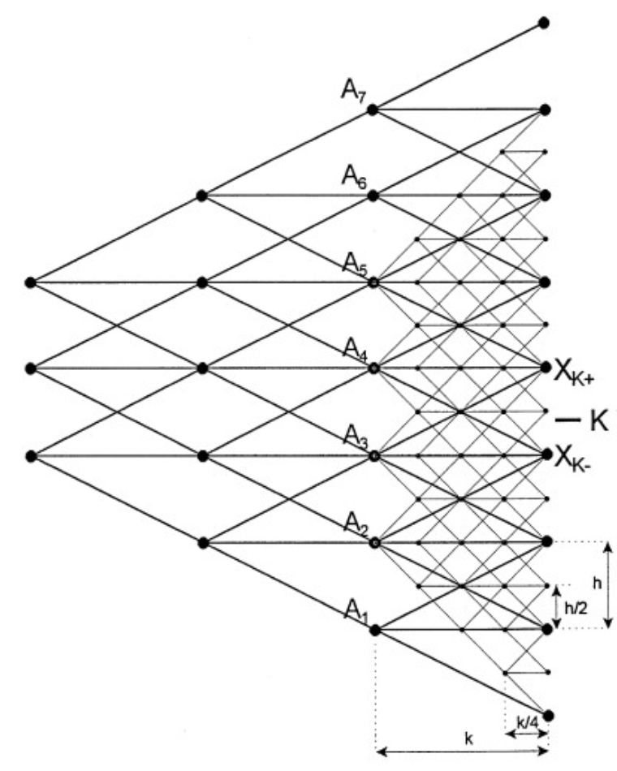

#### 蒙特卡罗模拟

##### 离散化的随机路径

- 为了模拟风险中性路径：$dS_{t} = S_{t}[(r-\delta)dt + \sigma dW_{t}] $,$d(lnS_{t}) = S_{t}[(r-\delta -\frac{1}{2}\sigma^{2})dt + \sigma dW_{t}] $
- 可以用时间间隔$\Delta t$较小的差分项来进行近似： $$ \Delta S_{t+\Delta t} = S_{t}^{(r-\delta -\frac{1}{2}\sigma^{2})\Delta t + \sigma \epsilon_{t}\sqrt{\Delta t}} $$ $$ \Delta S_{t} = S_{t+\Delta t} - S_{t} = S_{t}[(r-\delta)\Delta t + \sigma \epsilon_{t}\sqrt{\Delta t}] $$ $$ \Delta lnS_{t} = lnS_{t+\Delta t} - lnS_{t} = (r-\delta -\frac{1}{2}\sigma^{2})\Delta t + \sigma \epsilon_{t}\sqrt{\Delta t} $$
  - 其中，$S_t$代表t时刻S的价值， $ε_t$是从标准正态分布中抽取的一个随机样本。
  - 通过N个正态分布的随机抽样就可以组建一条在风险中性测度下资产价格的蒙特卡罗模拟样本路径，并得到相应的回报值。
  - 重复以上的模拟至足够多的次数，可以得到多条可能的路径。
  - 计算各条路径期权**到期回报的平均值$E_{Q}(X_{T}|\Bbb{F}_{t})$**，按无风险利率贴现后就得到了期权的估值，同时也可以得到期权价格的标准差
- 以上两种模拟路径中，用$ln S$比用$S$准确。
- 特别地，当用蒙特卡罗模拟为欧式期权定价时，由于期权回报只与期权到期时刻的标的价格有关，而与具体路径无关，因此，可以让 $t+Δt = T$并直接利用公式（12.11）来求T时刻的股票价格，可以大大节省计算时间。
- 如何确定迭代次数$n$?
  - 利用95%置信区间:$[\bar{V} - \frac{1.96*\hat{\sigma}}{\sqrt{n}},\bar{V} + \frac{1.96*\hat{\sigma}}{\sqrt{n}}]$
  - $\bar{V}$为期权价格均值，$\hat{sigma}$为波动率的估计值，$n$为迭代次数
  - 一般取$n = 10^{5}$

##### 主要优缺点

- 主要优点：
  - 运用简单直接，无需深刻理解期权定价模型
  - 可给出标准误和置信区间
  - 适用情形广泛
    - 欧式衍生产品
    - 回报路径依赖
    - 回报取决于多个标的资产
- 主要缺点：
  - 难以处理提前行权的情形
  - 为了达到一定的精确度，一般需要大量的模拟运算

### 第十三章 期权的交易策略及其运用

#### 单期权策略

##### 运用期权进行静态风险管理

- 静态风险管理，是指一次交易之后直至到期都不再调整的风险管理，它是和需要不断调整头寸的动态风险管理相对而言的。
- 运用期权对其他资产进行静态风险管理是通过进入期权多头实现的。
- 当时黄金现货价格为3930日元/克。假设某生产黄金的矿业公司认为黄金仍有上升空间，但也有可能大跌。为了防范黄金大跌的风险，该公司决定买入看跌期权。
- 该公司应该如何选择期权期限和行权价格呢？
  - 如果该公司认为黄金只可能短期调整，一般就买短期的期权；
  - 如果该公司认为黄金有可能进入大熊市，那就要买长期的期权。
    - 特别是平值期权，随着时间的延后,其价格只是按照时间的平方根增长。
    - 实值期权的价格增长速度则更慢。
  - 行权价格的选择也跟后市判断有关。如果该公司对后市很悲观，则要选择尽量高的行权价。如果较乐观，则可以选择较低的行权价。

##### 运用期权进行杠杆投资

- 与其他衍生产品一样，期权可以提供杠杆的作用
- 对于期权多头而言
  - 如果市场价格走势与其预期方向相同，一个小比例的价格变化会带来放大的收益
  - 如果市场价格走势与其预期方向相反，一个小比例的价格变化会带来放大的亏损
- 2020年1月23日,武汉宣布封城。如果投资者看空沪深300股价指数，则其有以下两种投资途径:
  1. 按1月23日开盘价4093.0点做空2月到期的沪深300股指期货IF2002。
  2. 按1月23日开盘价1.4点的价格买进2月到期、行权价为3600点的沪深300股指看跌期权。
- 从1月24曰到2月2日，中国股市因为春节假期休市。受疫情影响，2月3日股市开市后，中国股市大跌。
  - 到2月3日收盘，IF2002跌到3591.2点，2个交易日期货价格下跌12.26%,按股指期货10%的保证金计算，2个交易曰做空期货的收益率达到122.6%。
  - 而2月到期、行权价为3600点的沪深300股指看跌期权涨到133.0点，两个交易日涨幅高达9500%!
- 可见期权具有远高于期货的杠杆效应。

#### 期权组合策略及其运用

##### 期权组合

- 根据各自对未来标的资产价格概率分布的不同预期，以及自己的风险收益偏好，进行期权组合。
  - 包括标的资产与期权的组合、期权与期权的组合
  - 只要期权行权价足够多，组合种类是无限的
- 分析方法：
  - Payoff和Profit分布图
  - 盈亏状况分析表

##### 标的资产与期权的组合

1. 标的资产多头与看涨期权空头的组合（有担保的看涨期权空头）
   - 即“备兑开仓”
   - 相当于看跌期权空头

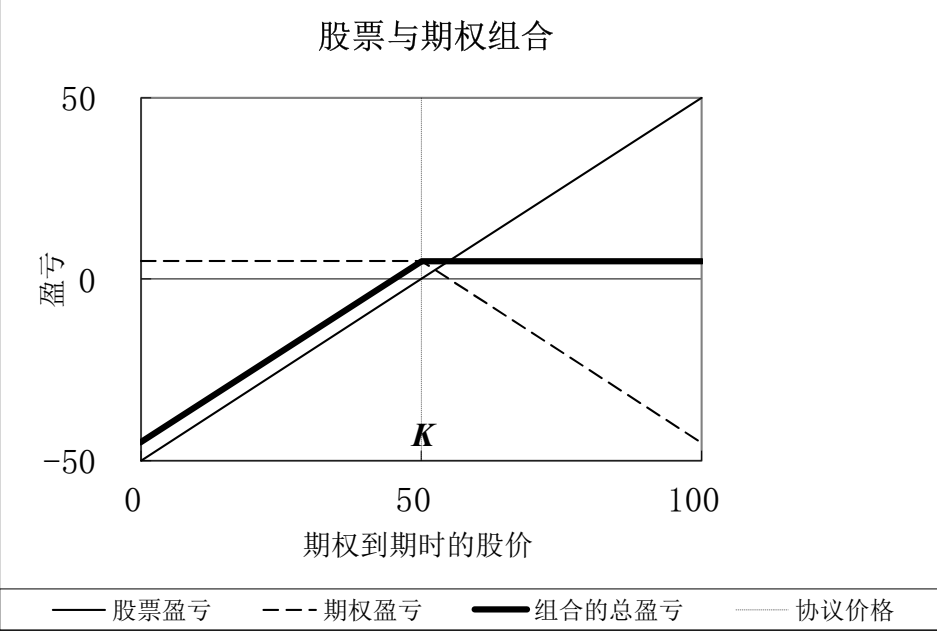

2. 标的资产多头与看跌期权多头的组合
   - 相当于看涨期权多头

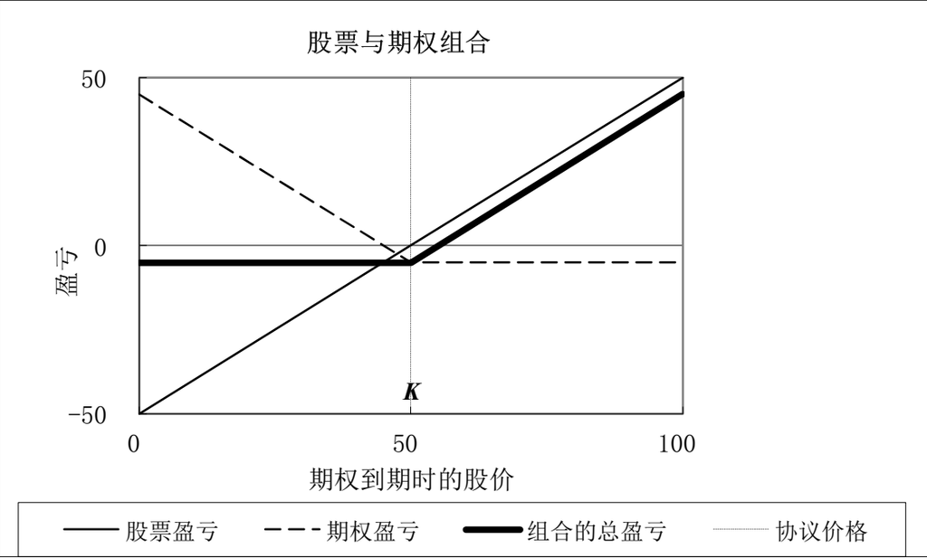

- 加上对手方的盈亏，可以得到4种组合：

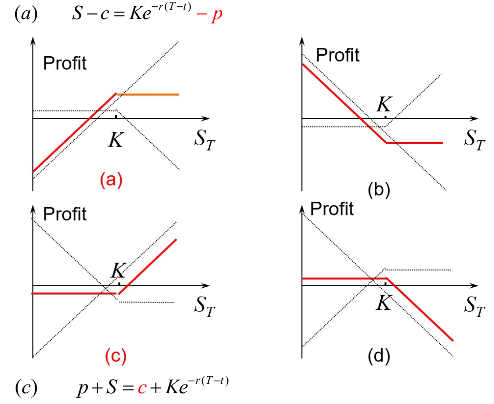

##### 期权与期权的组合

- 期权分类
  - 期权种类：看涨/看跌
  - 期权合约的具体规格：行权价/期限/多空
- 期权组合的种类
  - 差价组合
    - 牛市差价组合、熊市差价组合、蝶式差价组合
    - 同种期权，相同期限，不同行权价K
  - 差期组合
    - 同种期权，相同行权价，不同期限(T-t)
  - 对角组合：课外阅读，不作为考试要求
  - 混合期权
    - 跨式组合、条式组合、带式组合、勒式组合

##### 差价组合

- 持有相同期限、**不同行权价格**的两个或多个同种期权头寸组合（即同是看涨期权，或者同是看跌期权）。
- 其主要类型
  - 牛市差价组合（买低卖高,$K_{long}<K_{short}$）
  - 熊市差价组合（买高卖低,$K_{long}>K_{short}$）
  - 蝶式差价组合等(4份期权,3个行权价，$K_{2} = \frac{K_{1}+K_{3}}{2}$)

##### 牛市差价组合（Bull Spreads）（买低卖高）

1. 一份看涨期权多头 ＋ 一份同一期限较高行权价格的看涨期权空头

2. 一份看跌期权多头 ＋ 一份同一期限较高行权价格的看跌期权空头

##### 熊市差价组合

- 熊市差价组合(Bear Spreads）（买高卖低）
  1. 一份看涨期权多头＋一份相同期限、行权价格较低的看涨期权空头

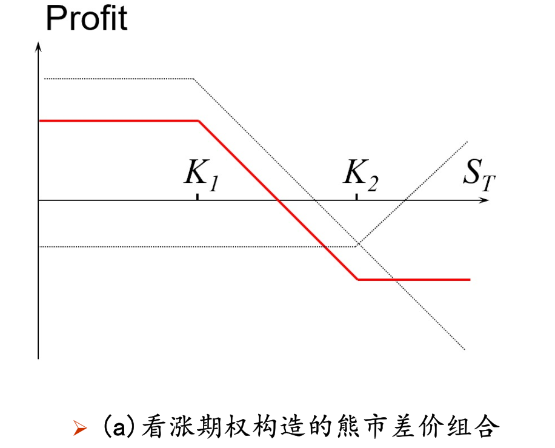

  2. 一份看跌期权多头＋一份相同期限、行权价格较低的看跌期权空头

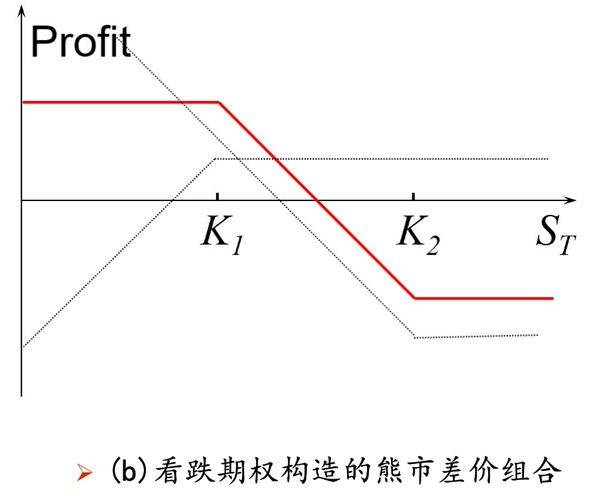

- 为何称“熊市差价组合”？
  - 到期日现货价格下跌对组合持有者较有利
- 初始现金流和最终的Payoff区别：
  - 看涨期权和看跌期权的熊市差价组合的差别在于前者在期初有正的现金流，后者在期初则有负的现金流，但后者的期末回报大于前者。
- 看涨期权构造组合：
  - \begin{matrix} price & X_1 & X_2 & Total Payoff \\ S_T< K_2 & 0 & 0 & 0 \\ K_2 < S_T < K_1 & 0 & K_2 - S_T & K_2 - S_T \\ S_T > K_1 & S_T - K_1 & K_2 - S_T & K_2 - K_1 \end{matrix}
- 看跌期权构造组合：

  \begin{matrix} price & X_1 & X_2 & Total Payoff \\ S_T< K_2 & K_1-S_T & S_T- K_2 & K_1 -K_2 \\ K_2 < S_T < K_1 & K_1-S_T & 0 & K_1-S_T \\ S_T > K_1 & 0 & 0 & 0 \end{matrix}
- 构建熊市差价组合的主要原因：
  - 投资者对后市较为悲观，但看跌期权价格整体太高使得买进看跌期权不太合算，而熊市差价组合可以规避期权绝对价格过高的问题；
  - 低行权价期权价格被高估，高行权价期权价格被低估，这时熊市差价组合的概率赔率组合较为有利。
- 熊市差价组合刚好跟牛市差价组合相反，两者的图形刚好以 x轴对称

##### 蝶式差价组合 Butterfly Spreads

- 蝶式差价组合由四份具有相同期限、不同行权价格的同种期权头寸组成。
- 若K1 < K2 < K3，且K2 = (K1 + K3)/2，则标准蝶式差价组合有如下四种：
- 构建蝶式差价组合的主要原因：
  - 正向：预期价格会在一定的区间内波动
  - 反向：预期价格会有较大的波动
- 蝶式差价组合的初始现金流
  - 正向：初始现金流为负
  - 反向：初始现金流为正
- 证明：无论用看涨期权还是看跌期权构造正向（反向）蝶式差价组合的回报都相同，并且初始投资也相同
- 考试时所指的蝶式差价组合指常规的情况
  - 所使用的期权都是平值期权
  - 行权价$K_2 = \frac{K_1+K_3}{2}$

##### 差期组合 Calendar Spreads

- 差期组合：两份相同行权价格、不同期限的同种期权的不同头寸组成
- 差期组合的四种类型
  - 正向差期组合（买长卖短）
    - 一份看涨期权多头与一份期限较短的看涨期权空头的组合，称看涨期权的正向差期组合。
    - 一份看跌期权多头与一份期限较短的看跌期权空头的组合，称看跌期权的正向差期组合。
  - 反向差期组合（买短卖长）
    - 一份看涨期权多头与一份期限较长的看涨期权空头的组合，称看涨期权的反向差期组合。
    - 一份看跌期权多头与一份期限较长的看跌期权空头的组合，称看跌期权的反向差期组合。

##### 混合期权

- 混合期权
  - 由不同种的期权——看涨和看跌组成的组合
  - 行权价格、期限、多空、份数等可以相同或不同
  - 底部(全部期权都是多头)/顶部(全部期权都是空头)

##### 跨式组合（ Straddle）

- 由具有相同行权价格、相同期限的一份看涨期权和一份看跌期权组成
- 底部跨式组合：两份多头组成
- 顶部跨式组合：两份空头组成

##### 条式组合（ Strip）

- 由具有相同行权价格、相同期限的一份看涨期权和两份看跌期权组成
- 条式组合也分底部和顶部两种，前者由多头构成，后者由空头构成
- 具有不对称性，底部条式适用于投资者预测价格变化较大，且下跌的可能大于上涨可能的情形

##### 带式组合（ Strap）

- 由具有相同行权价格、相同期限的资产的两份看涨期权和一份看跌期权组成
- 带式组合也分底部和顶部两种，前者由多头构成，后者由空头构成
- 具有不对称性，底部带式适用于投资者预测价格变化较大，且上升的可能大于下跌可能的情形

##### 勒式组合（ Strangle）

- 由相同到期日但行权价格不同的一份看涨期权和一份看跌期权组成，其中看涨期权的行权价格高于看跌期权
- 勒式组合也分底部和顶部，前者由多头组成，后者由空头组成
- 比较底部跨式、条式、带式和勒式期权组合：
  - 此类策略适合预期标的资产价格将有大幅波动但不能确定方向的投资者；
  - 跨式组合是对称的，条式和带式分别适合有一定预期偏好的投资者；
  - 相比跨式组合，勒式组合只有在股价有更大幅度波动时才可能获利，但其初始成本也相对较低，其收益特征取决于两个执行价格的接近程度